# Final project - 42578 Advanced Business Analytics Project Option 2: Olist - Product reviews and categories

By Andreas Kaae, s154395

Other group memebers: Henrik Foss Jørgensen - s153975, Peter Vilhelm Nyholm - s153634, Rasmus Peter Riber - s154060

This notebook is a part of a group assignment about investigating the data from the Brazilian e-commerce store Olist, however this part was only constructed by the author. This specific notebook will focus on customer review scores and comments as well as the the product categories that are more prone to customer dissatisfaction. The data used is generously provided by Olist and is downloaded from https://www.kaggle.com/olistbr/marketing-funnel-olist. An explantion of all the datafiles and their features can be found in the provided notebook `Data-Description.ipynp`. In the data company names are replaced with the names of Game of Thrones great houses.

# Table of Contents

```python
%%javascript
$.getScript('https://kmahelona.github.io/ipython_notebook_goodies/ipython_notebook_toc.js')
```

The notebook consists of the following sections

III) **Data preparation**  
In this section the data is prepared.The data is loaded an merged and hereafter filtered.

IV) **Initial data analytics**  
The section briefly explores the merged data.

V) **Critical product categories**  
This sections seeks to identify the product categories with a reasonable amount of orders that are most prone to bad reviews.

VI) **Single order customers vs. multiple order customers**  
This section looks into how the review scores are distributed for single and multiple order customers.

VII) **Reviews over time**  
In this section the time of the reviews is considerede to see if there are any trends for product categories and bad reviews.

VIII) **Causes for bad reviews**  
The section looks into the possible causes for bad reviews by I) lookind at late deliveries and II) Analysing the review comments.

IX) **Conclusion**  
A conclusion highlighting some of the main findings.

Initially packages which are used thorughout the notebook are importet.

```python
import pandas as pd
import numpy as np
import matplotlib.pyplot as plt
import seaborn as sns
```

# Data preparation

In this section the data is loaded, merged and filtered.

## Load and merge data

The csv files provided from Olist which are relevant are loaded.

```python
products = pd.read_csv("data/olist_products_dataset.csv")
products.head(3)
```

|  | product_id | product_category_name | product_name_lenght | product_description_lenght | product_photos_qty | product_weight_g | product_length_cm | product_height_cm | product_width_cm |
| --- | --- | --- | --- | --- | --- | --- | --- | --- | --- |
| 0 | 1e9e8ef04dbcff4541ed26657ea517e5 | perfumaria | 40.0 | 287.0 | 1.0 | 225.0 | 16.0 | 10.0 | 14.0 |
| 1 | 3aa071139cb16b67ca9e5dea641aaa2f | artes | 44.0 | 276.0 | 1.0 | 1000.0 | 30.0 | 18.0 | 20.0 |
| 2 | 96bd76ec8810374ed1b65e291975717f | esporte_lazer | 46.0 | 250.0 | 1.0 | 154.0 | 18.0 | 9.0 | 15.0 |

```python
order_items = pd.read_csv("data/olist_order_items_dataset.csv")
order_items.head(3)
```

|  | order_id | order_item_id | product_id | seller_id | shipping_limit_date | price | freight_value |
| --- | --- | --- | --- | --- | --- | --- | --- |
| 0 | 00010242fe8c5a6d1ba2dd792cb16214 | 1 | 4244733e06e7ecb4970a6e2683c13e61 | 48436dade18ac8b2bce089ec2a041202 | 2017-09-19 09:45:35 | 58.9 | 13.29 |
| 1 | 00018f77f2f0320c557190d7a144bdd3 | 1 | e5f2d52b802189ee658865ca93d83a8f | dd7ddc04e1b6c2c614352b383efe2d36 | 2017-05-03 11:05:13 | 239.9 | 19.93 |
| 2 | 000229ec398224ef6ca0657da4fc703e | 1 | c777355d18b72b67abbeef9df44fd0fd | 5b51032eddd242adc84c38acab88f23d | 2018-01-18 14:48:30 | 199.0 | 17.87 |

```python
orders = pd.read_csv("data/olist_orders_dataset.csv")
orders.head(3)
```

|  | order_id | customer_id | order_status | order_purchase_timestamp | order_approved_at | order_delivered_carrier_date | order_delivered_customer_date | order_estimated_delivery_date |
| --- | --- | --- | --- | --- | --- | --- | --- | --- |
| 0 | e481f51cbdc54678b7cc49136f2d6af7 | 9ef432eb6251297304e76186b10a928d | delivered | 2017-10-02 10:56:33 | 2017-10-02 11:07:15 | 2017-10-04 19:55:00 | 2017-10-10 21:25:13 | 2017-10-18 00:00:00 |
| 1 | 53cdb2fc8bc7dce0b6741e2150273451 | b0830fb4747a6c6d20dea0b8c802d7ef | delivered | 2018-07-24 20:41:37 | 2018-07-26 03:24:27 | 2018-07-26 14:31:00 | 2018-08-07 15:27:45 | 2018-08-13 00:00:00 |
| 2 | 47770eb9100c2d0c44946d9cf07ec65d | 41ce2a54c0b03bf3443c3d931a367089 | delivered | 2018-08-08 08:38:49 | 2018-08-08 08:55:23 | 2018-08-08 13:50:00 | 2018-08-17 18:06:29 | 2018-09-04 00:00:00 |

```python
order_reviews = pd.read_csv("data/olist_order_reviews_dataset.csv")
order_reviews.head(3)
```

|  | review_id | order_id | review_score | review_comment_title | review_comment_message | review_creation_date | review_answer_timestamp |
| --- | --- | --- | --- | --- | --- | --- | --- |
| 0 | 7bc2406110b926393aa56f80a40eba40 | 73fc7af87114b39712e6da79b0a377eb | 4 | NaN | NaN | 2018-01-18 00:00:00 | 2018-01-18 21:46:59 |
| 1 | 80e641a11e56f04c1ad469d5645fdfde | a548910a1c6147796b98fdf73dbeba33 | 5 | NaN | NaN | 2018-03-10 00:00:00 | 2018-03-11 03:05:13 |
| 2 | 228ce5500dc1d8e020d8d1322874b6f0 | f9e4b658b201a9f2ecdecbb34bed034b | 5 | NaN | NaN | 2018-02-17 00:00:00 | 2018-02-18 14:36:24 |

```python
customers = pd.read_csv("data/olist_customers_dataset.csv")
customers.head(3)
```

|  | customer_id | customer_unique_id | customer_zip_code_prefix | customer_city | customer_state |
| --- | --- | --- | --- | --- | --- |
| 0 | 06b8999e2fba1a1fbc88172c00ba8bc7 | 861eff4711a542e4b93843c6dd7febb0 | 14409 | franca | SP |
| 1 | 18955e83d337fd6b2def6b18a428ac77 | 290c77bc529b7ac935b93aa66c333dc3 | 9790 | sao bernardo do campo | SP |
| 2 | 4e7b3e00288586ebd08712fdd0374a03 | 060e732b5b29e8181a18229c7b0b2b5e | 1151 | sao paulo | SP |

Below all 5 dataframes are merged on either `product_id`, `order_id` or `customer_id`.

```python
temp = products.merge(order_items, on='product_id', how='outer')
temp = temp.merge(order_reviews, on = 'order_id', how='outer')
temp = temp.merge(orders, on = 'order_id', how='outer')
temp = temp.merge(customers,on = 'customer_id', how='outer')
df_all = temp
df_all.shape
```

```
(114100, 32)
```

We thus end up with a dataframe with 114100 observations and 32 featurs. However many of these features are not used. The columns used in this notebook are specified below and the dataframe is restriced to this.

```python
features_used = ['product_category_name','review_score','review_comment_message','order_id',
                 'customer_unique_id','customer_id','order_delivered_customer_date',
                 'price','product_id','order_estimated_delivery_date','order_purchase_timestamp']

df = df_all[features_used]
df.shape
```

```
(114100, 11)
```

This limites the dataframe to 11 features.

## Checking the data

Beneath the dataset is checked for nan values. It can be seen that there are 2390 observations which does not have a product category name. These observations will be removed as eventhough they might have a review score it is not possible to connect them to the product category.

```python
df.isna().sum()
```

```
product_category_name             2390
review_score                         0
review_comment_message           64965
order_id                             0
customer_unique_id                   0
customer_id                          0
order_delivered_customer_date     3253
price                              778
product_id                         778
order_estimated_delivery_date        0
order_purchase_timestamp             0
dtype: int64
```

```python
df = df.dropna(subset = ['product_category_name'])
df.isna().sum()
```

```
product_category_name                0
review_score                         0
review_comment_message           63839
order_id                             0
customer_unique_id                   0
customer_id                          0
order_delivered_customer_date     2408
price                                0
product_id                           0
order_estimated_delivery_date        0
order_purchase_timestamp             0
dtype: int64
```

There are still nan values left in the dataset. However, as there are no nan's in `product_category_name` or `product_category_name` we leave the dataset for now. Lastly we reset the index.

```python
df = df.reset_index()
df = df.drop(['index'],axis=1)
```

## Removing duplicates

The dataset is made so each row corrosponds to an item ordered from Olist. Thereby if an order has multiple items within, it will also have multiple lines in the dataset.

```python
# Amount of orders
print("Amount of items bought from Olist:",df.shape[0])

# Orders
print("Amount of orders:",len(df.order_id.unique()))

# Customers
print("Amount of customers:",len(df.customer_unique_id.unique()))
```

```
Amount of items bought from Olist: 111710
Amount of orders: 97277
Amount of customers: 94108
```

The data set consist of 111710 items bought from Olist. These items are dividede between 97277 orders purchased by 94108 customers. This means that some customers have made orders with multiple items in them and that some customers have bought from Olist multiple times. It also means that the review scores will be replicated several times if an order consist of more than one order. An example of this is row 8 to 11.

```python
df[8:12]
```

|  | product_category_name | review_score | review_comment_message | order_id | customer_unique_id | customer_id | order_delivered_customer_date | price | product_id | order_estimated_delivery_date | order_purchase_timestamp |
| --- | --- | --- | --- | --- | --- | --- | --- | --- | --- | --- | --- |
| 8 | moveis_decoracao | 2 | Na entrega veio faltando os dois assento futon... | 6ecf7023e8dd4ec8b08746c35b9fcb60 | 8fe54925e8ff1067c803ae7026fe384b | 181e2217f874cb5390be37f378db5e07 | 2017-12-07 09:38:30 | 9.99 | 2548af3e6e77a690cf3eb6368e9ab61e | 2017-12-19 00:00:00 | 2017-11-24 14:22:48 |
| 9 | moveis_decoracao | 2 | Na entrega veio faltando os dois assento futon... | 6ecf7023e8dd4ec8b08746c35b9fcb60 | 8fe54925e8ff1067c803ae7026fe384b | 181e2217f874cb5390be37f378db5e07 | 2017-12-07 09:38:30 | 9.99 | 2548af3e6e77a690cf3eb6368e9ab61e | 2017-12-19 00:00:00 | 2017-11-24 14:22:48 |
| 10 | moveis_decoracao | 2 | Na entrega veio faltando os dois assento futon... | 6ecf7023e8dd4ec8b08746c35b9fcb60 | 8fe54925e8ff1067c803ae7026fe384b | 181e2217f874cb5390be37f378db5e07 | 2017-12-07 09:38:30 | 39.90 | 140a8324a66db81d299b24b30d93098e | 2017-12-19 00:00:00 | 2017-11-24 14:22:48 |
| 11 | moveis_decoracao | 2 | Na entrega veio faltando os dois assento futon... | 6ecf7023e8dd4ec8b08746c35b9fcb60 | 8fe54925e8ff1067c803ae7026fe384b | 181e2217f874cb5390be37f378db5e07 | 2017-12-07 09:38:30 | 39.90 | 140a8324a66db81d299b24b30d93098e | 2017-12-19 00:00:00 | 2017-11-24 14:22:48 |

We here see an order which consists of 4 different items and 2 different products (as there is two different `product_id`) however the `review_score`, the `review_comment_message` etc. is the same for all rows. So to avoid that the `review_score` and the `review_comment_message` is counted for more than once we delete the duplicates and leave one row for each order. The index is reset afterwords.

```python
df = df.drop_duplicates(['order_id'])
df = df.reset_index()
df = df.drop(['index'],axis=1)
df.shape
```

```
(97277, 11)
```

The dataframe now consist of 97277 rows, one for each order.

## Translating category names

As the dataset is from a Brazilian e-commerce company the `product_category_name` is in portugese which will be translated using the provided file `product_category_name_translation.csv`.

```python
## Load translation file
translation = pd.read_csv("data/product_category_name_translation.csv")
translation.head(3)
```

|  | product_category_name | product_category_name_english |
| --- | --- | --- |
| 0 | beleza_saude | health_beauty |
| 1 | informatica_acessorios | computers_accessories |
| 2 | automotivo | auto |

```python
print("Amount of product categorys in translation:",len(translation['product_category_name']))
print("Amount of product categorys in data:",len(df['product_category_name'].unique()))
```

```
Amount of product categorys in translation: 71
Amount of product categorys in data: 73
```

There is a problem as we have more product categories in the data than in the translation. We therefor need to find which categories are missing in the translation dataframe.

```python
#Define a vectore specifying if the category in the data also is in the translation
isin = df['product_category_name'].isin(translation['product_category_name'])
temp = []

# For loop to find missing categories
for i in df['product_category_name'].index:
    if isin[i] == False:
         print(df['product_category_name'][i])
```

```
pc_gamer
pc_gamer
pc_gamer
pc_gamer
pc_gamer
portateis_cozinha_e_preparadores_de_alimentos
portateis_cozinha_e_preparadores_de_alimentos
pc_gamer
pc_gamer
portateis_cozinha_e_preparadores_de_alimentos
portateis_cozinha_e_preparadores_de_alimentos
portateis_cozinha_e_preparadores_de_alimentos
portateis_cozinha_e_preparadores_de_alimentos
pc_gamer
portateis_cozinha_e_preparadores_de_alimentos
portateis_cozinha_e_preparadores_de_alimentos
portateis_cozinha_e_preparadores_de_alimentos
portateis_cozinha_e_preparadores_de_alimentos
portateis_cozinha_e_preparadores_de_alimentos
portateis_cozinha_e_preparadores_de_alimentos
portateis_cozinha_e_preparadores_de_alimentos
portateis_cozinha_e_preparadores_de_alimentos
```

```python
new_categories = pd.DataFrame([['pc_gamer','pc_gamer'],
                              ['portateis_cozinha_e_preparadores_de_alimentos',
                              'portable_kitchen_and_food_preparers']],
                              columns = ['product_category_name','product_category_name_english'])

translation = translation.append(new_categories, ignore_index=True)
translation.tail(4)
```

|  | product_category_name | product_category_name_english |
| --- | --- | --- |
| 69 | fashion_roupa_infanto_juvenil | fashion_childrens_clothes |
| 70 | seguros_e_servicos | security_and_services |
| 71 | pc_gamer | pc_gamer |
| 72 | portateis_cozinha_e_preparadores_de_alimentos | portable_kitchen_and_food_preparers |

The block of code below creates the new column in the dataframe with the product category names in english `product_category_name_eng`. The code is however outcommented as it takes some time time to run. The dataframe with the column is saved as 'export_df.csv' and loaded underneath.

```python
# # Creating the column for the category name in english
# eng_names = []
# for label, row in df.iterrows():
#     for i in range(0,len(translation)):
#         if row['product_category_name'] == translation['product_category_name'][i]:
#             eng_names.append(translation['product_category_name_english'][i])

# df['product_category_name_eng'] = eng_names
# df.head()
```

```python
# # Loading the datafram with english category names.
# df.to_csv(r'C:\Users\Andreas Kaae\Documents\DTU\8. semester (Start kandidat)\Advanced Business Analytics\Final project\data\export_df.csv')
```

```python
df = pd.read_csv('data/export_df.csv')
df = df.drop(['Unnamed: 0'],axis=1)
df.head()
```

|  | product_category_name | review_score | review_comment_message | order_id | customer_unique_id | customer_id | order_delivered_customer_date | price | product_id | order_estimated_delivery_date | order_purchase_timestamp | product_category_name_eng |
| --- | --- | --- | --- | --- | --- | --- | --- | --- | --- | --- | --- | --- |
| 0 | perfumaria | 5 | Super adooorei o delineador ele é bem preto e ... | e17e4f88e31525f7deef66779844ddce | b1a1199364a4a7fe27c4486ab63f550d | f8a3e963a310aa58b60a5b1fed5bceb5 | 2018-04-27 16:42:17 | 10.91 | 1e9e8ef04dbcff4541ed26657ea517e5 | 2018-05-09 00:00:00 | 2018-04-24 16:16:53 | perfumery |
| 1 | artes | 5 | Excelente apontador! Em 3 segundos uma ponta p... | 5236307716393b7114b53ee991f36956 | 4b86049cb99e4aa774031daa9cd18f18 | 03fc97548af8f58fefc768d12b546c9c | 2018-02-16 13:27:08 | 248.00 | 3aa071139cb16b67ca9e5dea641aaa2f | 2018-02-22 00:00:00 | 2018-01-31 18:55:36 | art |
| 2 | esporte_lazer | 5 | NaN | 01f66e58769f84129811d43eefd187fb | f63805d9c7edb84d92413af34b86a39c | e41819d1c95c12c9ce495b630eab8aee | 2018-07-11 23:24:16 | 79.80 | 96bd76ec8810374ed1b65e291975717f | 2018-07-18 00:00:00 | 2018-07-09 21:18:01 | sports_leisure |
| 3 | bebes | 1 | modelo comprado: travesseiro memoria carinho B... | 143d00a4f2dde4e0364ee1821577adb3 | 619e926d09b26efbd5180368b1ddc874 | 322162b5ca010c2b059cb5224dd818b1 | 2018-08-06 15:14:32 | 112.30 | cef67bcfe19066a932b7673e239eb23d | 2018-08-08 00:00:00 | 2018-08-03 08:55:50 | baby |
| 4 | utilidades_domesticas | 5 | NaN | 86cafb8794cb99a9b1b77fc8e48fbbbb | ad353b4fb0e294adc4eda48af73e68a6 | c11c31965ff02cc1d7132df8edfcbc22 | 2018-04-13 22:41:44 | 37.90 | 9dc1a7de274444849c219cff195d0b71 | 2018-04-26 00:00:00 | 2018-04-11 01:06:37 | housewares |

# Initial data analytics

To get a better understand of the data we will initially look into some fundamental insights of the data to see how it is distributed. Initially we will look at some summary statistics.

```python
df.describe()
```

|  | review_score | price |
| --- | --- | --- |
| count | 97277.000000 | 97277.000000 |
| mean | 4.091903 | 126.029803 |
| std | 1.341662 | 190.982980 |
| min | 1.000000 | 0.850000 |
| 25% | 4.000000 | 41.900000 |
| 50% | 5.000000 | 79.000000 |
| 75% | 5.000000 | 139.900000 |
| max | 5.000000 | 6735.000000 |

We there by see that the mean rating is 4.09 and that the mean price of an order i 126.

To see how the review scores a distributed a bar plot is made.

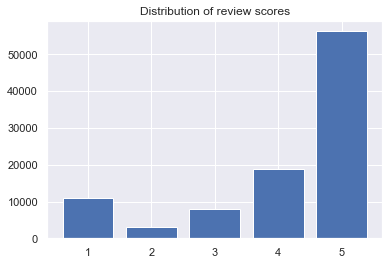

```
Customers who gave a rating below 5: 40996
Customers who gave rating of 5: 56281
14.514222272479621 % of the ratings are bad reviews
```

```python
## Define and plotting the review scores which are plottet.
sns.set(rc={'figure.figsize':(6, 4)})
height = df.groupby(['review_score']).count()['product_id']
labels = height.index
plt.bar(labels,height)
plt.title("Distribution of review scores")
plt.show()

print("Customers who gave a rating below 5:", df.groupby(['review_score']).count()['product_id'][0:4].sum())
print("Customers who gave rating of 5:", df.groupby(['review_score']).count()['product_id'][5])
print(sum(height[0:2]) / sum(height)*100,'% of the ratings are bad reviews')
```

We thus have that people in general give very high ratings as 5 is the most common review score. We also see that there actually are more people who give the rating of 5 than all of the other ratings together. It is also noticable that the score of 2 and 3 are the most uncommon ones, this could indicate that when customers give an review they are often either very satisfied or not statisfied at all.

Through out the notebook the term 'bad review' will be used about a review of score 1 or 2. As seen there are 14.5 % bad reviews in the data.

We would furthermore like to see how many orders each category has.

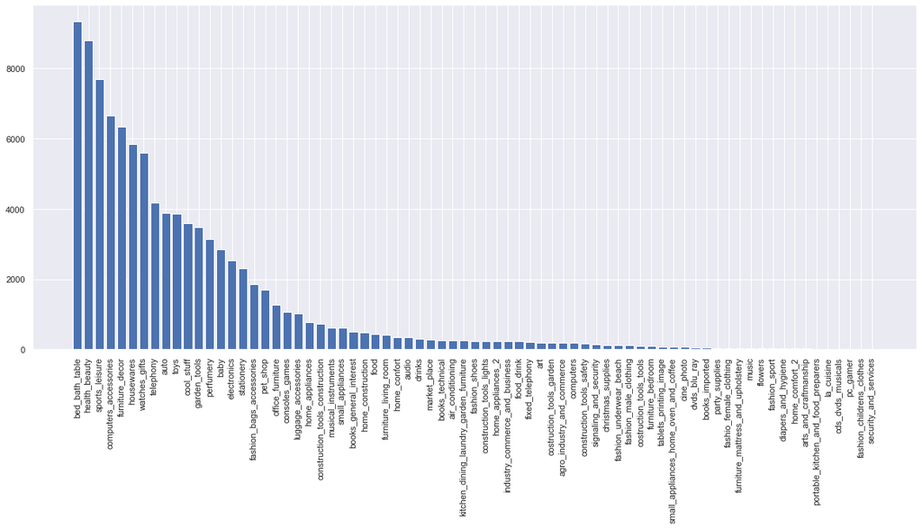

```
15 biggest categories make up: 79.9736833989535 %
Different categories in the dataset: 73
```

```python
sns.set(rc={'figure.figsize':(20, 8)})
size = df.groupby(['product_category_name_eng'])['review_score'].count()
size = size.sort_values(ascending=False)
plt.bar(size.index,size)
plt.xticks(rotation=90)
plt.show()

print("15 biggest categories make up:",sum(size[0:15])/sum(size)*100,"%")
print("Different categories in the dataset:", len(df['product_category_name_eng'].unique()))
```

We can thereby see that we have 73 product categories in total and that there is a big difference between how many orders each category has. Just 15 categories for example make up almost 80% of all orders.

# Identifying critical product categories

In this section we would like to see how the ratings are distributed across the product categories to determine if some categories are more prone to bad reviews than others. Therefor the mean of the product reviews are first plotted for all categories

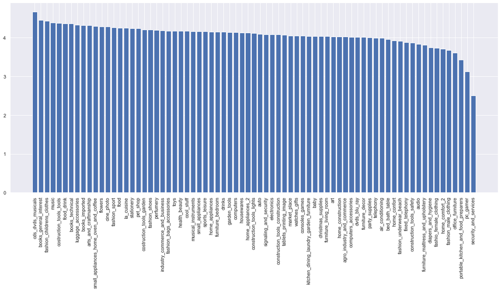

```python
sns.set(rc={'figure.figsize':(20, 8)})
size = df.groupby(['product_category_name_eng'])['review_score'].mean()
size = size.sort_values(ascending=False)
plt.bar(size.index,size)
plt.xticks(rotation=90)
plt.show()
```

From this it can be seen that most categories are very close to the mean review score of 4. The last 5 categories are significant lower than that and therefor seem to be prone to more bad reviews. However, from a business perspective it does only make sense to look at a category if it acutally has a resonable amount of orders. As seen in the previous section the amount of orders in each category differ significant from each category. To have a better idea of which categories are interesting to look at both with regards to bad reviews while taking into account the total amount of orders, a plot showing the following is illustrated:

- Numbers of orders within a category divided with the total amount of orders.
- The total amount bad reviews for at category divided with the total amount of bad reviews for all categories.

With these two measures for each category the categories which have a large share of the bad reviews are easily spotted, however this ratio will be next to that categories share of all orders. If a category has a smaller amount of bad reviews than the amount of orders it means that this category is doing well, however if it has a larger share of bad reviews than it has of the orders then we might want to look into this category.

```python
# Define a column specifying wheter an order is bad or good (1 = bad, 0 = good)
df['bad_reviews'] = (df['review_score'] < 3)*1
```

The amount of bad reviews, sales and total amount of reviews are found for each category.

```python
# Define the amount of bad reviews and total reviews for each category
bad_reviews = df[df['bad_reviews']==1].groupby(['product_category_name_eng']).count()['review_score']

#Define amount of reviews/orders:
reviews = df.groupby(['product_category_name_eng']).count()['review_score']
```

To be able to compare bad reviews, sales and total amount of reviews they have to be divided by the total amount. A new dataframe only containing these ratios is made and hereafter plotted.

```python
# Create a datafram for the ratios
df_ratio = pd.DataFrame()
df_ratio['bad_reviews'] = bad_reviews/sum(bad_reviews)
df_ratio['reviews'] = reviews/sum(reviews)

# Fill the missing values as some categories do not have any bad reviews.
df_ratio = df_ratio.fillna(0)
```

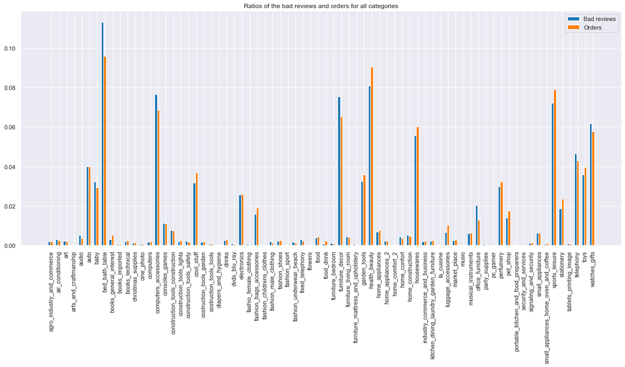

```python
## Plot the to ratios together for comparison.
sns.set(rc={'figure.figsize':(20, 8)})
barWidth = 0.3
r1 = np.arange(len(df_ratio.index))
r2 = [x + barWidth for x in r1]



plt.bar(r1,df_ratio['bad_reviews'],width = barWidth,label='Bad reviews',color = 'tab:blue')
plt.bar(r2,df_ratio['reviews'],width = barWidth,label='Orders',color = 'tab:orange')
plt.legend()
plt.xticks([r + barWidth for r in range(len(df_ratio.index))], df_ratio.index, rotation=90)
plt.title("Ratios of the bad reviews and orders for all categories")
plt.show()
```

Of the categories discussed `bed_bath_table`, `computers_accessories` and `furniture_decor` are choosen as these have a much higher ratio of bad reviews than their ratio of orders. The categories are also some of the biggest categories with regards to amount of orders (all are within top 15) and improving on these can therefor potential give a lot of additional good reviews. `office_furniture` is also choosen as it had one of the lowest mean review scores and has a noticable amount of orders.

Below theses categories are plotted alone to be able to clearly see the distribution between them. Furthermore the amount of bad orders out of the total amount of orders within that category is added to the plot.

```python
# The interesting categories discussed above are defined
categories = ['bed_bath_table','computers_accessories','furniture_decor','office_furniture']
```

```python
# Amount of bad orders for categories
bad_orders_categories = df[df['bad_reviews'] == 1].groupby(['product_category_name_eng']).count()['review_score']
# Amount of orders for categories
order_categories = df.groupby(['product_category_name_eng']).count()['review_score']
```

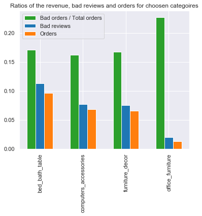

```
Mean scores for choosen product categories
product_category_name_eng
bed_bath_table           3.958972
computers_accessories    4.019349
furniture_decor          4.009449
office_furniture         3.613869
Name: review_score, dtype: float64
```

```python
## Plot the to ratios together for comparison.
sns.set(rc={'figure.figsize':(6, 5)})
barWidth = 0.2
r1 = np.arange(len(df_ratio['bad_reviews'][categories].index))
r2 = [x + barWidth for x in r1]
r3 = [x + barWidth for x in r2]

plt.bar(r1, bad_orders_categories[categories]/order_categories[categories], width = barWidth,
        label = 'Bad orders / Total orders', color = 'tab:green')
plt.bar(r2,df_ratio['bad_reviews'][categories],width = barWidth,
        label='Bad reviews', color = 'tab:blue')
plt.bar(r3,df_ratio['reviews'][categories],width = barWidth,
        label='Orders', color = 'tab:orange')
plt.legend()
plt.xticks([r + barWidth for r in range(len(df_ratio['bad_reviews'][categories].index))], df_ratio['bad_reviews'][categories].index, rotation=90)
plt.title("Ratios of the revenue, bad reviews and orders for choosen categoires")
plt.show()

print('Mean scores for choosen product categories')
print(df.groupby(['product_category_name_eng']).mean()['review_score'][categories])
```

Thereby 4 product categories which are critical with regads to bad reviews have been choosen. For the three categories `bed_bath_table`, `computers_accesorries` and `furniture_decor` around 15% of the reviews given are bad reviews. For the product category `office_furniture` more than 20% of the reviews given are bad reviews, however this category is also responsible for a much smaller amount of all orders.

# Single order customers vs. multiple order customers

A very obvious reason for Olist to want good reviews is to acquire new customers, if Olist have a bad rating many customers will look else where to make their purchase. Another reason for wanting good reviews could be with regards to returning customers. It is therefor interesting to understand if customers who made a single order and customers who made multiple orders give different ratings. To do this we use the `customer_unique_id` which is a unique id for each specific customers. Firstly let us recall how many customers we have and see how many bought from Olist multiple times.

```python
print("Different customers:",len(df['customer_unique_id'].unique()))
print("Bought from Olist multiple times:",sum(df.groupby(['customer_unique_id']).count()['review_score']>1))
print(sum(df.groupby(['customer_unique_id']).count()['review_score']>1)/len(df['customer_unique_id'].unique())*100)
```

```
Different customers: 94108
Bought from Olist multiple times: 2850
3.0284354146299997
```

We have 94108 customers in total of which 2850 customers bought from Olist multiple times, which is only 3%. We now want to define a dataframe with all the orders made by customers who only bought from Olist once and one with the customers who bought from Olist multiple times. Initially we find the `customer_unique_id` for the customers who bought multiple items from Olist and thereafter create the dataframes.

```python
# Find the id for the unique customers
unique_customers_multiple = (df.groupby(['customer_unique_id']).count()['review_score'] > 1)*1
unique_customers_multiple = unique_customers_multiple[unique_customers_multiple == 1].index
len(unique_customers_multiple)
```

```
2850
```

```python
# Define dateframe with only the customers who bought multiple orders
df_multiple_order = df[df['customer_unique_id'].isin(unique_customers_multiple)*1 == 1]

#Define datafram with only the customers who made a single orders
df_single_order = df[df['customer_unique_id'].isin(unique_customers_multiple)*1 == 0]

print(df_multiple_order.shape[0] + df_single_order.shape[0])
```

```
97277
```

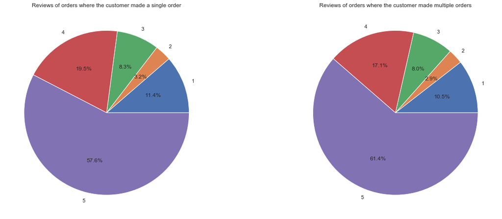

```
Mean review score for customers with multiple orders: 4.159993354377804
Mean review score for customer with a single order: 4.087411514606939
```

```python
# Define the review scores
size_multiple_order = df_multiple_order.groupby(['review_score']).count()['product_id']
size_single_order = df_single_order.groupby(['review_score']).count()['product_id']

#plot
sns.set(rc={'figure.figsize':(20, 8)})
labels = '1', '2', '3', '4', '5'
fig, (ax1,ax2) = plt.subplots(1,2)
ax1.pie(size_single_order, labels=labels, autopct='%1.1f%%')
ax2.pie(size_multiple_order, labels=labels, autopct='%1.1f%%')
ax1.set_title('Reviews of orders where the customer made a single order')
ax2.set_title('Reviews of orders where the customer made multiple orders')
plt.show()

#print mean reviw scores
print("Mean review score for customers with multiple orders:",df_multiple_order['review_score'].mean())
print("Mean review score for customer with a single order:",df_single_order['review_score'].mean())
```

From the mean scores we see that the mean value is higher for the customers who bought multiple orders. In the pie-charts it can be seen that this is because the share of the review score of 5 is larger for customers who made multiple orders while the share of the other review scores are decreased. This also means that there is 14.6% bad reviews from customers who made a single order and 13.4% bad reviews from the customers who made multiple orders. This thereby indicates that the people who makes multiple orders generally gives a little better reviews and thereby are more satisfied.

Another interesting question is to look at the review scores of the first orders made by the customers who made multiple orders. This is interesting as it can give an idea of if the customers made multiple orders because they were statisfied with their first order.

The code below constructs a new dataframe, `df_early`, which only has the first order for each of the customers who made multiple orders. Some customers made two or more orders at the excat same time, for these orders the first order is simply choosen. The code is outcommented as it takes a minute or two to run. The dataframe is saved and loaded below as the file `df_early.csv`.

```python
# #df_early = pd.DataFrame(columns=[df.columns])
# df_early = pd.DataFrame()

# #customers = test
# customers = df_multiple_order['customer_unique_id'].unique()

# for i in range(0,len(customers)):
#     temp1 = [customers[i]]
#     temp2 = df_multiple_order[df_multiple_order['customer_unique_id'].isin(temp1)*1 == 1]
#     earliest = min(temp2['order_purchase_timestamp'])

#     # Some customers made several orders at the excat same time. For these customers
#     # the first of these orders is used.
#     temp3 = temp2[temp2['order_purchase_timestamp'] == earliest]
#     df_early = df_early.append(temp3.iloc[0])

# df_early.to_csv(r'C:\Users\Andreas Kaae\Documents\DTU\8. semester (Start kandidat)\Advanced Business Analytics\Final project\data\df_early.csv')
```

```python
df_early = pd.read_csv('data/df_early.csv')
# Set index
df_early = df_early.set_index('Unnamed: 0')
# Delete index column name
del df_early.index.name
df_early.head()
```

|  | bad_reviews | customer_id | customer_unique_id | order_delivered_customer_date | order_estimated_delivery_date | order_id | order_purchase_timestamp | price | product_category_name | product_category_name_eng | product_id | review_comment_message | review_score |
| --- | --- | --- | --- | --- | --- | --- | --- | --- | --- | --- | --- | --- | --- |
| 61627 | 0.0 | 6d1d259349c3354c9a4afefefc776b4c | a518c60e2e7f3a2820b4ef5cf5107189 | 2017-09-25 09:42:44 | 2017-10-05 00:00:00 | 927a6b1ef2d0f3d510b0aa14885919ff | 2017-09-20 23:02:46 | 119.99 | cool_stuff | cool_stuff | 66a0a6e02b7f543e5b021ce361f267d4 | Otimo produto!\r\nLindas.. | 5.0 |
| 73731 | 0.0 | 16322e237a07158592862b5d6d91642d | ed42ccde391485cde5b0699b84b5c070 | 2018-02-14 17:07:38 | 2018-02-23 00:00:00 | f9985288469173749a1fd05693c5aa2b | 2018-02-01 11:57:55 | 24.90 | moveis_decoracao | furniture_decor | 7cb2ff3193293db892fd5697aa99a19b | NaN | 5.0 |
| 89718 | 1.0 | 35ec6c1ca9e5844c5ca94214cce16dca | b854c56e1163bced9c3ebf1e4a6576f3 | 2018-03-22 00:03:53 | 2018-03-16 00:00:00 | 33a3edb84b9df4cb49546859b990ac6d | 2018-02-21 17:15:49 | 49.90 | ferramentas_jardim | garden_tools | 389d119b48cf3043d311335e499d9c6b | Minha opinião é que se comprei o produto ele t... | 1.0 |
| 55369 | 0.0 | abd49ba4cf56e622b951f281361f56ad | 94e5ea5a8c1bf546db2739673060c43f | 2016-10-31 13:27:40 | 2016-11-29 00:00:00 | 64f5569ef96004a1e1137bdf28fd4c45 | 2016-10-05 21:10:56 | 54.90 | fashion_roupa_feminina | fashio_female_clothing | ecac086eca2f806295b1f43b4f6ca119 | Ótimo vendedor, ótimo produto chegou no prazo ... | 5.0 |
| 75 | 0.0 | 070db51ef1d6a1bd858c21b03de83e66 | 1f98e3467d2b48dfb44fc12b137d3447 | 2016-10-15 15:09:06 | 2016-11-30 00:00:00 | f9c44da06151c190a9a6c9c712873d10 | 2016-10-08 22:11:57 | 83.90 | bebes | baby | b864b103180d5a6a3f830e67f93e8735 | Ótimo produto | 5.0 |

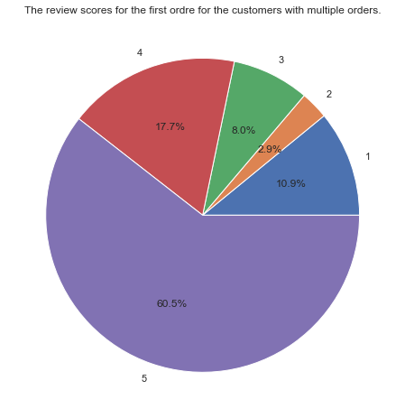

```
Mean review score of the first order for the customers with multiple orders: 4.140701754385965
```

```python
size = df_early.groupby(['review_score']).count()['customer_unique_id']
labels = '1', '2', '3', '4', '5'

plt.pie(size,labels=labels,autopct='%1.1f%%')
plt.title("The review scores for the first ordre for the customers with multiple orders.")
plt.show()
print("Mean review score of the first order for the customers with multiple orders:",df_early['review_score'].mean())
```

The mean review score is a little bit lower for the first order compared to the pie chart with all orders for the returning customers. The total amount of bad reviews are 13.8%, so again a little worse.

The difference in the review score is not significant between the customers making one or multiple orders. There therefor does not seem to be any correlation between giving a good score on the first order and making a second order. Improving the ratings will therefor not help Olist to increase the amount of returning customers.

# Reviews over time

This section will investigate the reviews by looking at them over time. This can reveal any periods of the year with more bad reviews or any trends of the reviews. For the time of the review the feature `order_purchase_timestamp` is used which specifies the timestamp of the purchase. This is used as this date will show the current state of the company at that time. The feature `review_creation_date` could also have been used but as the reviews can be created long after the order is received this would not be directly related to anything happening in the company at that time.

To investigate this we will look at the mean review score, the ratio of the bad reviews and the different review score over time. The tool `resample` is used to accumulate observations over different time periods. This function can only resample over numbers so a column specifying if an observations is an order is needed.

```python
# A new column is created, which is 1 all observations in the df as all are orders.
df['is_order'] = 1
df.head()
```

|  | product_category_name | review_score | review_comment_message | order_id | customer_unique_id | customer_id | order_delivered_customer_date | price | product_id | order_estimated_delivery_date | order_purchase_timestamp | product_category_name_eng | bad_reviews | is_order |
| --- | --- | --- | --- | --- | --- | --- | --- | --- | --- | --- | --- | --- | --- | --- |
| 0 | perfumaria | 5 | Super adooorei o delineador ele é bem preto e ... | e17e4f88e31525f7deef66779844ddce | b1a1199364a4a7fe27c4486ab63f550d | f8a3e963a310aa58b60a5b1fed5bceb5 | 2018-04-27 16:42:17 | 10.91 | 1e9e8ef04dbcff4541ed26657ea517e5 | 2018-05-09 00:00:00 | 2018-04-24 16:16:53 | perfumery | 0 | 1 |
| 1 | artes | 5 | Excelente apontador! Em 3 segundos uma ponta p... | 5236307716393b7114b53ee991f36956 | 4b86049cb99e4aa774031daa9cd18f18 | 03fc97548af8f58fefc768d12b546c9c | 2018-02-16 13:27:08 | 248.00 | 3aa071139cb16b67ca9e5dea641aaa2f | 2018-02-22 00:00:00 | 2018-01-31 18:55:36 | art | 0 | 1 |
| 2 | esporte_lazer | 5 | NaN | 01f66e58769f84129811d43eefd187fb | f63805d9c7edb84d92413af34b86a39c | e41819d1c95c12c9ce495b630eab8aee | 2018-07-11 23:24:16 | 79.80 | 96bd76ec8810374ed1b65e291975717f | 2018-07-18 00:00:00 | 2018-07-09 21:18:01 | sports_leisure | 0 | 1 |
| 3 | bebes | 1 | modelo comprado: travesseiro memoria carinho B... | 143d00a4f2dde4e0364ee1821577adb3 | 619e926d09b26efbd5180368b1ddc874 | 322162b5ca010c2b059cb5224dd818b1 | 2018-08-06 15:14:32 | 112.30 | cef67bcfe19066a932b7673e239eb23d | 2018-08-08 00:00:00 | 2018-08-03 08:55:50 | baby | 1 | 1 |
| 4 | utilidades_domesticas | 5 | NaN | 86cafb8794cb99a9b1b77fc8e48fbbbb | ad353b4fb0e294adc4eda48af73e68a6 | c11c31965ff02cc1d7132df8edfcbc22 | 2018-04-13 22:41:44 | 37.90 | 9dc1a7de274444849c219cff195d0b71 | 2018-04-26 00:00:00 | 2018-04-11 01:06:37 | housewares | 0 | 1 |

To be able to plot the observations later we need to have the time as the index.

```python
# Create new dataframe with timestamp as index
df_datetime = df.set_index(pd.DatetimeIndex(df['order_purchase_timestamp']))
```

A new dateframe which resamples for all months is created below. The ratio for the bad reviews is also made.

```python
# Resample over weeks
df_datetime_W = df_datetime.resample('M').sum()

# Make a new column for the ratio of bad reviews out of total reviews
df_datetime_W['ratio'] = df_datetime_W['bad_reviews']/df_datetime_W['is_order']

# Replace NaN values
df_datetime_W['ratio'] = df_datetime_W['ratio'].fillna(0)
df_datetime_W.head()
```

| order_purchase_timestamp | review_score | price | bad_reviews | is_order | ratio |
| --- | --- | --- | --- | --- | --- |
| 2016-09-30 | 3 | 137.39 | 3 | 3 | 1.000000 |
| 2016-10-31 | 1113 | 45138.19 | 82 | 306 | 0.267974 |
| 2016-11-30 | 0 | 0.00 | 0 | 0 | 0.000000 |
| 2016-12-31 | 5 | 10.90 | 0 | 1 | 0.000000 |
| 2017-01-31 | 3173 | 106939.28 | 119 | 778 | 0.152956 |

The ratio for all observations and for each of the categories is plotted below. Furthermore the amount of orders for a month divided with the total amount of orders in the data is also plotted. This line is made to indicate if there are sudden rises in the total amount of orders in a month.

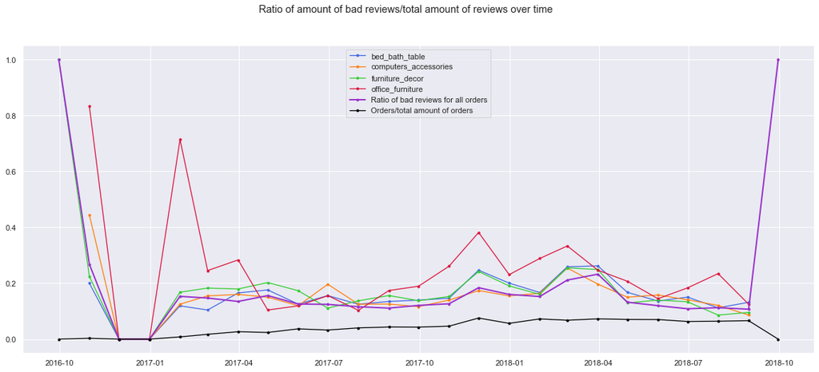

```python
## The two lines below are to avoid error messages
from pandas.plotting import register_matplotlib_converters
register_matplotlib_converters()

# The time window which is resampled over
resample_time = 'M'

# Define categories to plot
cat = categories

# Define colors
colors = ['royalblue', 'tab:orange','limegreen','crimson']

# Plot
fig, ax = plt.subplots()
fig.suptitle("Ratio of amount of bad reviews/total amount of reviews over time")
## For loop plotting for each of the specified categories
for i in range(0,len(cat)):
    temp = df_datetime[df_datetime['product_category_name_eng'] == cat[i]]
    temp_resample = temp.resample(resample_time).sum()
    temp_ratio = temp_resample['bad_reviews']/temp_resample['is_order']
    temp_ratio = temp_ratio.fillna(0)
    #plot category
    ax.plot(temp_ratio, marker='.', linewidth=1.3, label=cat[i], color = colors[i])
# plot all observations
ax.plot(df_datetime_W['ratio'], marker='.', linewidth=2.0,
        label='Ratio of bad reviews for all orders', color = 'darkorchid')
# plot orders/(total amount of orders)
ax.plot(df_datetime_W.is_order/sum(df_datetime_W.is_order),marker='.',
        linewidth=1.3, label='Orders/total amount of orders', color = 'black')
ax.legend()
plt.show()
```

In the plot the resampeling is kept at a monthly basis as if sampling over weeks too much detail was captured, and again, if sampeling over years too little detail could be captured. From the plot the following things are noted.

- In the beginning (up until 2017-01) the company does not have many orders. This can be seen from the black line as a very small percentage of all the orders are in the first months. This is also the explanation to that purple and green line starts at ratio of 1.0, which indicates that in the first month all the reviews were bad. This is probably in the beginning phases of the company when they had very few orders.
- Three of the 4 product categories do not have any reviews before the second month '2016-11'.
- In the last month, 2018-10, there is very few observations and no observations for the choosen categories.
- In 2017-12 the amount of bad reviews rises for all categories and at the same time the amount of orders rises. This might be because of the Christmas period where more orders are placed than normal (which means more bad reviews).
- In the period of 2018-03 to 2018-04 all categories, but 'office_furniture', and the overall ratio reach their maximum ratio while the black line (Orders/total amonut of orders) stays unchanged. The increased amount of bad reviews are therefor not because of a sudden increase in orders.
- The category 'office_furniture', which was the category which had the lowest mean review score of the categoreis, also generally has the worst ratio. In the beginning months this category has a lot of bad reivews, which could indicate some start up problems.

It can thus be concluded that for the period of time which is provided the ratio of bad ratings fluctuate alot but overall does not seem to be rising over time. There also seems to be time periods with more bad reviews than others. To further investigate the mean score for the different categories as well as the overall mean score is plotted.

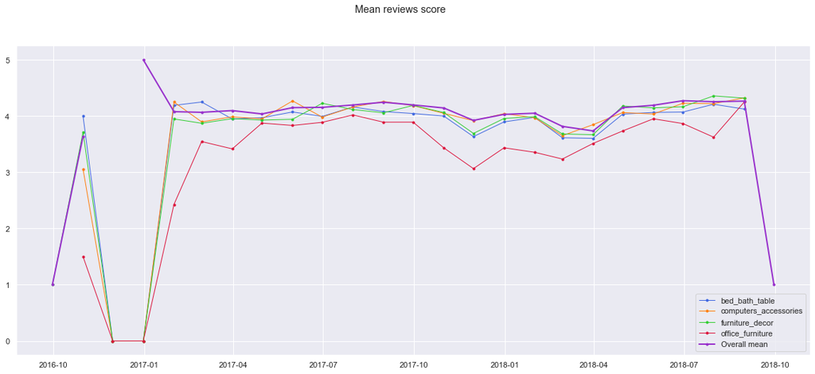

```python
## The two lines below are to avoid error messages
from pandas.plotting import register_matplotlib_converters
register_matplotlib_converters()

# The time window which is resampled over
resample_time = 'M'

# Define categories to plot
cat = categories

# Plot
fig, ax = plt.subplots()
fig.suptitle("Mean reviews score")
## For loop plotting for each of the specified categories
for i in range(0,len(cat)):
    temp = df_datetime[df_datetime['product_category_name_eng'] == cat[i]]
    temp_resample = temp.resample(resample_time).mean()
    temp_rev = temp_resample['review_score']
    temp_rev = temp_rev.fillna(0)
    #plot category
    ax.plot(temp_rev, marker='.', linewidth=1.0, label=cat[i], color = colors[i])
# plot all observations
ax.plot(df_datetime['review_score'].resample('M').mean(), marker='.', linewidth=2,
        label='Overall mean', color = 'darkorchid')
ax.legend()
plt.show()
```

Similar findings as made from the previous plot is found and further enlightend.

It can thus be concluded that the ratings are neither rising or decreasing over time and that there seems to be certain periods where the mean ratings and amount of bad reviews are higher. Finally we will look at the different review scores for all categories over time.

```python
# Define data for each review score and resample over weeks.
time = 'W'
review_score1 = df_datetime[df_datetime['review_score'] == 1]['review_score'].resample(time).count()
review_score2 = df_datetime[df_datetime['review_score'] == 2]['review_score'].resample(time).count()
review_score3 = df_datetime[df_datetime['review_score'] == 3]['review_score'].resample(time).count()
review_score4 = df_datetime[df_datetime['review_score'] == 4]['review_score'].resample(time).count()
review_score5 = df_datetime[df_datetime['review_score'] == 5]['review_score'].resample(time).count()
```

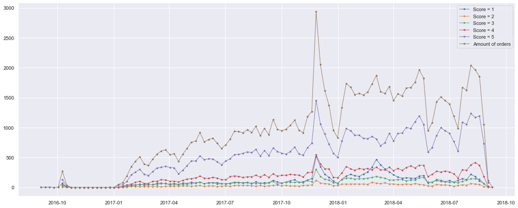

```python
## The two lines below are to avoid error messages
from pandas.plotting import register_matplotlib_converters
register_matplotlib_converters()

fig, ax = plt.subplots()
#Plot reviews scores
ax.plot(review_score1, marker='.', linewidth=1.0, label='Score = 1')
ax.plot(review_score2, marker='.', linewidth=1.0, label='Score = 2')
ax.plot(review_score3, marker='.', linewidth=1.0, label='Score = 3')
ax.plot(review_score4, marker='.', linewidth=1.0, label='Score = 4')
ax.plot(review_score5, marker='.', linewidth=1.0, label='Score = 5')
#Plot amount of orders
ax.plot(df_datetime['is_order'].resample(time).count(),marker='.', linewidth=1.0, label='Amount of orders')
ax.legend()
plt.show()
```

In this plot the data is resampled over weeks as this allows us to see more details. The plot illustrated above confirms the observations made earlier about the time periods but allows us to see more closely what happens. From analysing the plot the following observations are made.

- The review score of 5 is by far the most common review score no matter the time.
- The amount of review scores flucuate from each week.
- One week stands out with the highest amount of review scores. After this week there is also a high amount of bad reviews.
- The period spotted in the previous plots (2018-03 to 2018-04) with the high ratio of bad reviews can directly be seen here as the score of 1 for three weeks has the second highest amount of reviews.
- The amount of orders are generally increasing eventhough they fluctuate from week to week.

In a later section the review comments are analyzed. We therefor want to find out which weeks the week with the most amount or orders is and the week where the score of 1 clearly is the second most common review score as we want to see what the problems were during these weeks.

```python
# Define start and end start date for the "Christmas week".
print("Start date for week with most amount of orders:",np.argmax((review_score5)))
christmasW_start = '2017-11-26 00:00:00'
christmasW_end = '2017-12-02 23:59:59'

# Define start and end date for the week where the review score of 1 is second highest
datefrom = review_score1['2018-01-01':]
print("Start date for week where review score of 1 is second highest:",np.argmax((datefrom)))
rev1W_start = '2018-03-04 00:00:00'
rev1W_end = '2018-03-10 23:59:59'
```

```
Start date for week with most amount of orders: 2017-11-26 00:00:00
Start date for week where review score of 1 is second highest: 2018-03-04 00:00:00
```

With the specific dates identified the review scores can be plotted for each day to see more details.

```python
# Define data for each review score and resample over weeks.
time = 'D'
review_score1 = df_datetime[df_datetime['review_score'] == 1]['review_score'].resample(time).count()
review_score2 = df_datetime[df_datetime['review_score'] == 2]['review_score'].resample(time).count()
review_score3 = df_datetime[df_datetime['review_score'] == 3]['review_score'].resample(time).count()
review_score4 = df_datetime[df_datetime['review_score'] == 4]['review_score'].resample(time).count()
review_score5 = df_datetime[df_datetime['review_score'] == 5]['review_score'].resample(time).count()
```

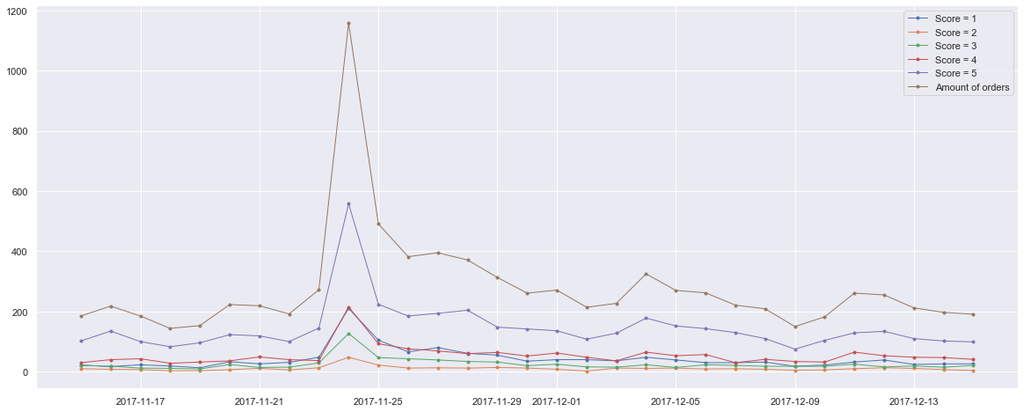

```python
## The two lines below are to avoid error messages
from pandas.plotting import register_matplotlib_converters
register_matplotlib_converters()

start = '2017-11-15'
end = '2017-12-15'

fig, ax = plt.subplots()
#Plot reviews scores
ax.plot(review_score1[start:end], marker='.', linewidth=1.0, label='Score = 1')
ax.plot(review_score2[start:end], marker='.', linewidth=1.0, label='Score = 2')
ax.plot(review_score3[start:end], marker='.', linewidth=1.0, label='Score = 3')
ax.plot(review_score4[start:end], marker='.', linewidth=1.0, label='Score = 4')
ax.plot(review_score5[start:end], marker='.', linewidth=1.0, label='Score = 5')
#Plot amount of orders
ax.plot(df_datetime['is_order'].resample(time).count()[start:end],marker='.', linewidth=1.0, label='Amount of orders')
ax.legend()
plt.show()
```

```python
bf_start = '2017-11-22 00:00:01'
bf_end = '2017-11-24 23:59:59'
```

To find the dates where the review score of 1 is the second highest, a interval around the before found date is plotted.

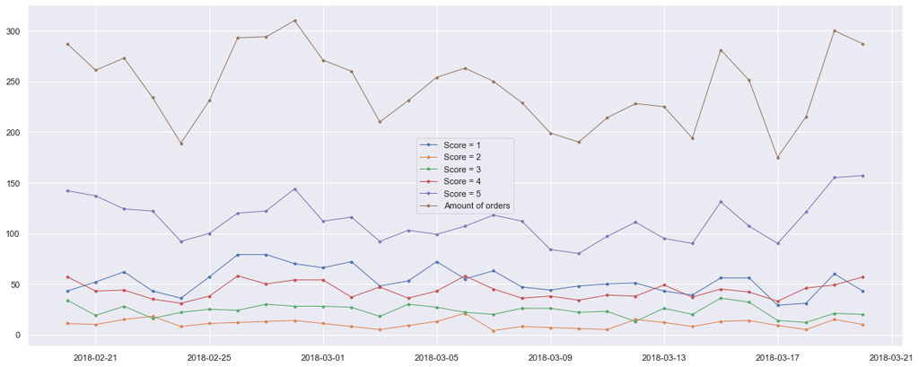

```python
## The two lines below are to avoid error messages
from pandas.plotting import register_matplotlib_converters
register_matplotlib_converters()

start = '2018-02-20'
end = '2018-03-20'

fig, ax = plt.subplots()
#Plot reviews scores
ax.plot(review_score1[start:end], marker='.', linewidth=1.0, label='Score = 1')
ax.plot(review_score2[start:end], marker='.', linewidth=1.0, label='Score = 2')
ax.plot(review_score3[start:end], marker='.', linewidth=1.0, label='Score = 3')
ax.plot(review_score4[start:end], marker='.', linewidth=1.0, label='Score = 4')
ax.plot(review_score5[start:end], marker='.', linewidth=1.0, label='Score = 5')
#Plot amount of orders
ax.plot(df_datetime['is_order'].resample(time).count()[start:end],marker='.', linewidth=1.0, label='Amount of orders')
ax.legend()
plt.show()
```

From the plot above it can be seen that from '2018-02-25' to '2018-03-02' the review score of 1 is the second highest. This time period is therefor saved below.

```python
rev1_high_start = '2018-02-25 00:00:01'
rev1_high_end = '2018-03-02 23:59:59'
```

```python
# Define start and end date for the interval 2017-07 to 2017-10:
normalW1_start = '2017-08-13 00:00:00'
normalW1_end = '2017-08-19 23:59:59'

# Define start and end date for the interval 2018-05 to 2018-08:
normalW2_start = '2018-06-24 00:00:00'
normalW2_end = '2018-07-30 23:59:49'
```

From analysing the reviews over time it is thereby concluded that no general trend is seen over time. Two interesting time periods were however discovered, 1) Black Friday, which had by far the most amount of orders and reviews and 2) a period where there were more bad reviews than normal. Besides this it was found that the different product categories generally follow the same trend but that the category 'office_furniture' generally had the worst ratings of the 4 choosen categories.

# Causes for bad reviews

This section will look into potential reason for the bad reviews, first by looking at late deliveries and after by analyzing the review comments.

## Late deliveries

One reason for a bad review could be because of the order being late. To check this we need to check if `order_estimated_delivery_date` is larger than `order_delivered_customer_date`. As showed earlier there were some nan values for the feature `order_delivered_customer_date` which first must be removed.

```python
df = df.dropna(subset = ['order_delivered_customer_date'])
```

To use the dates they need to be converted into datetime. This is also done for all other columns which have a date.

```python
date_columns = ['order_purchase_timestamp','order_delivered_customer_date',
                'order_estimated_delivery_date']

for column in date_columns:
    df[column] = pd.to_datetime(df[column], format="%Y-%m-%d %H:%M:%S")
```

```python
## Print some results:
print(sum(df['order_estimated_delivery_date'][:] < df['order_delivered_customer_date'][:]),
          "late deliveries out of", df.shape[0],"deliveries.")
print("This gives:", (sum(df['order_estimated_delivery_date'][:] < df['order_delivered_customer_date'][:])
                        /df.shape[0])*100,"% late deliveries" )
```

```
7708 late deliveries out of 95144 deliveries.
This gives: 8.101404187337089 % late deliveries
```

There are thereby 8.1% late deliveries in the dataset. A binary column specifying if a order is on time or not is added to the dataframe as `late`. The column is 0 if the order is on time and 1 if it is late.

```python
# Constructing the column 'late'. It is multiplied by 1 to change the value from True or Fale to 1 or 0.
df['late'] = (df['order_estimated_delivery_date'][:] < df['order_delivered_customer_date'][:])*1
```

To see how the late orders are distributed across the categories a barplot is made.

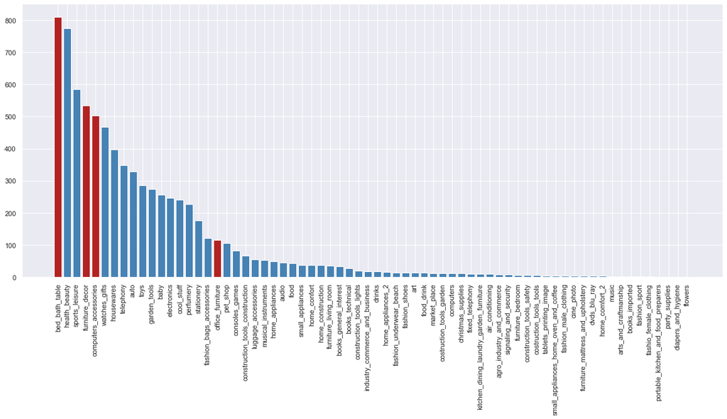

```python
sns.set(rc={'figure.figsize':(20, 8)})
size = df[df['late'] == 1].groupby(['product_category_name_eng']).count()['review_score']
size = size.sort_values(ascending=False)
col = ['steelblue']*len(size)
col[0] = 'firebrick'
col[4] = 'firebrick'
col[3] = 'firebrick'
col[17] = 'firebrick'
plt.bar(size.index,size,color = col)
plt.xticks(rotation=90)
plt.show()
```

The 4 chosen categories are highlighted with red. We see that 3 of the choosen categories are among the top 5 categories which have the biggest amount of late reviews. The choosen category `office_furniture` has a lot less late deliveries, however this category also had fewer total orders.

To evaluate the amount of late deliveries against everything else a ratio of late deliveries for each category against the total amount of late deliveries is constructed and added to the `df_ratio` dataframe.

```python
# Define total amount of late deliveries
total_late = df.groupby(['product_category_name_eng']).sum()['late'].sum()

# Add the late ratio to the df_ratio dataframe
df_ratio['ratio_late'] = df.groupby(['product_category_name_eng']).sum()['late']/total_late
```

We now want to see how the ratio of late orders is compared to the ratio of orders for each category.

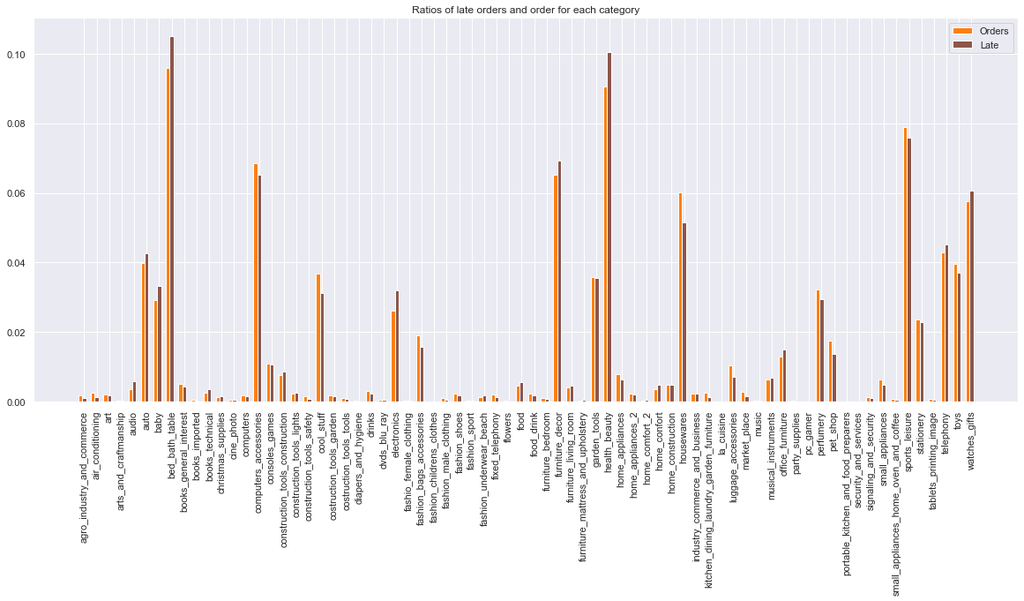

```python
## Plot the two ratios together for comparison.
sns.set(rc={'figure.figsize':(20, 8)})
barWidth = 0.3
r1 = np.arange(len(df_ratio.index))
r2 = [x + barWidth for x in r1]

plt.bar(r1,df_ratio['reviews'],width = barWidth,label='Orders', color = 'tab:orange')
plt.bar(r2,df_ratio['ratio_late'],width = barWidth,label='Late', color = 'tab:brown')
plt.legend()
plt.xticks([r + barWidth for r in range(len(df_ratio.index))], df_ratio.index, rotation=90)
plt.title("Ratios of late orders and order for each category")
plt.show()
```

From the plot we can see that generally the ratio of late orders is similar to the ratio of orders. This indicates that the larger the product category is the more late deliveries it will also have. To study the choosen categories better a plot for only these is made where the ratio of bad reviews is also included.

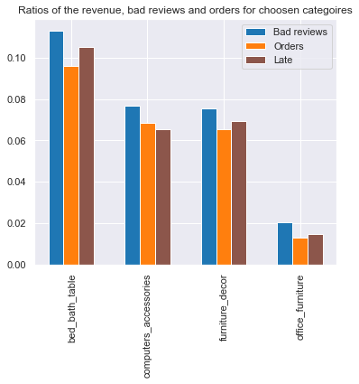

```python
## Plot the to ratios together for comparison.
sns.set(rc={'figure.figsize':(6, 5)})

barWidth = 0.2
r1 = np.arange(len(df_ratio['bad_reviews'][categories].index))
r2 = [x + barWidth for x in r1]
r3 = [x + barWidth for x in r2]
r4 = [x + barWidth for x in r3]
r5 = [x + barWidth for x in r4]

plt.bar(r1,df_ratio['bad_reviews'][categories],width = barWidth,
        label='Bad reviews', color = 'tab:blue')
plt.bar(r2,df_ratio['reviews'][categories],width = barWidth,
        label='Orders', color = 'tab:orange')
plt.bar(r3,df_ratio['ratio_late'][categories],width = barWidth,
       label='Late', color = 'tab:brown')

plt.legend()
plt.xticks([r + barWidth for r in range(len(df_ratio['bad_reviews'][categories].index))],
           df_ratio['bad_reviews'][categories].index, rotation=90)
plt.title("Ratios of the revenue, bad reviews and orders for choosen categoires")
plt.show()
```

The plot shows that for the 4 categories the ratio of late orders is proportional to the amount of orders. We also want to know how many % of the orders within the 4 categories are late, for comparison the amount of orders with bad reviews is also plotted together with it.

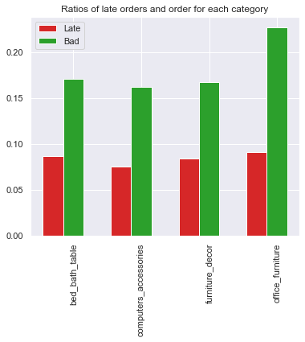

```python
late_order_categories = df.groupby(['product_category_name_eng']).sum()['late']
## Plot the two ratios together for comparison.
sns.set(rc={'figure.figsize':(6,5)})
barWidth = 0.3
r1 = np.arange(len(late_order_categories[categories].index))
r2 = [x + barWidth for x in r1]

plt.bar(r1,late_order_categories[categories]/order_categories[categories],
        width = barWidth,label='Late', color = 'tab:red')
plt.bar(r2,bad_orders_categories[categories]/order_categories[categories],
        width = barWidth,label='Bad', color = 'tab:green')

plt.legend()
plt.xticks([r + barWidth for r in range(len(late_order_categories[categories].index))],
           late_order_categories[categories].index, rotation=90)
plt.title("Ratios of late orders and order for each category")
plt.show()
```

It shows that 8-9% of the orders for each category are late, which is very close to the overall average of 8.1%. We also see that the % of bad reviews is much higher for all categories which means that all bad reviews cannot be because of the order being late.

To dig further into a late order, we will look at what kind of reviews the deliveries which are late have. If a late delivery often gives a bad review it would indicate that reducing the amount of late deliveries could improve the ratings. A new dataframe with only late orders, `df_late`, is made.

```python
# We only want to look at all the observations which are late. We therefor define a new datafram for this
df_late = df[df['late'] == 1]
df_late.head()
```

|  | product_category_name | review_score | review_comment_message | order_id | customer_unique_id | customer_id | order_delivered_customer_date | price | product_id | order_estimated_delivery_date | order_purchase_timestamp | product_category_name_eng | bad_reviews | is_order | late |
| --- | --- | --- | --- | --- | --- | --- | --- | --- | --- | --- | --- | --- | --- | --- | --- |
| 30 | moveis_decoracao | 1 | NaN | ccebf8871fd33d082a64082120ce4e80 | eba22785df6a0869a23e654da590e35c | 131be65fea5d4d3e9220e739366fd3ea | 2017-08-23 19:51:39 | 111.90 | 1c1890ba1779090cd54008a3c3302921 | 2017-08-17 | 2017-08-04 12:52:51 | furniture_decor | 1 | 1 | 1 |
| 44 | malas_acessorios | 1 | Não sei como a lannister resolve usar o própri... | 27d90e6110e8c6168bf04f4efc4b936e | 61ab48f850b699b36a2d6f41dd2baafd | bb91a87e6f70b1bc048ac871f664acec | 2018-02-28 19:07:37 | 349.90 | f6574524b07d5bb753bab6f35abe2d06 | 2018-02-21 | 2018-01-22 10:40:09 | luggage_accessories | 1 | 1 | 1 |
| 53 | ferramentas_jardim | 1 | NaN | efac22dd2be7399535968466224f162d | 3438b8441c857ae2e12fb185b58ec074 | 996ff76de5c41d5364a85263137689da | 2018-06-08 12:58:40 | 199.00 | e1d1d22e9f8122a4ec1533b032c12562 | 2018-05-24 | 2018-05-01 19:14:15 | garden_tools | 1 | 1 | 1 |
| 55 | moveis_escritorio | 1 | Prazo de 40 dias e ainda sim passa do prazo | 1c1975ccdbd34c48a241f30cc2258dbb | 5845b9ba0fc652731bc389c5600302e0 | 4b8aa85bd0844a2cfa46261b1afd9386 | 2018-03-07 17:48:47 | 89.99 | 1eba879220bd0981a0e2fbab499ed4e1 | 2018-02-22 | 2017-12-20 22:44:00 | office_furniture | 1 | 1 | 1 |
| 83 | cool_stuff | 5 | e uma loja muito boa \r\n | 1b147191d6c1f8ce8f2cf5d52f3e9c49 | 4b21dfe700fe0a91adb2a7b582c16d56 | 84f4d00f0e0abcb7c517b950857b4728 | 2017-07-27 16:08:40 | 572.00 | 5f504b3a1c75b73d6151be81eb05bdc9 | 2017-07-18 | 2017-06-20 10:53:15 | cool_stuff | 0 | 1 | 1 |

Initially we look at the distribution of all the review scores for the late orders.

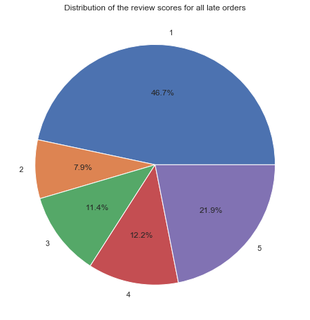

```
Mean review score 2.5476128697457185
33.71822628498116 % of bad reviews were also late, which is 4205 orders.
```

```python
sns.set(rc={'figure.figsize':(8, 8)})
size = df_late.groupby(['review_score']).count()['order_id']
labels = size.index
plt.pie(size,labels=labels,autopct='%1.1f%%')
plt.title("Distribution of the review scores for all late orders")
plt.show()

print('Mean review score', df_late['review_score'].mean())
print(size[0:2].sum()/df['bad_reviews'].sum()*100,'% of bad reviews were also late, which is',
      size[0:2].sum(),'orders.')
```

From the pie chart we see that the late orders definitly are getting worse ratings as the mean is 2.5 and 54.6% of the rating are bad reviews.

We now want to see if the same is true for the 4 chosen categories. We therefor need to filter the data so we only have the orders which are late and at the same time are a part of the defined categories. This dataframe is called `df_category_late`.

```python
# Define a new column specifying if one of the categories in 'categories' is in the df_late
# 1 indicates that the observation is among the categories and 0 otherwise.
df_late['category'] = df_late['product_category_name_eng'].isin(categories)*1

# Define a new dateframe only for the categories.
df_category_late = df_late[df_late['category'] == 1]
df_category_late.head()
```

|  | product_category_name | review_score | review_comment_message | order_id | customer_unique_id | customer_id | order_delivered_customer_date | price | product_id | order_estimated_delivery_date | order_purchase_timestamp | product_category_name_eng | bad_reviews | is_order | late | category |
| --- | --- | --- | --- | --- | --- | --- | --- | --- | --- | --- | --- | --- | --- | --- | --- | --- |
| 30 | moveis_decoracao | 1 | NaN | ccebf8871fd33d082a64082120ce4e80 | eba22785df6a0869a23e654da590e35c | 131be65fea5d4d3e9220e739366fd3ea | 2017-08-23 19:51:39 | 111.90 | 1c1890ba1779090cd54008a3c3302921 | 2017-08-17 | 2017-08-04 12:52:51 | furniture_decor | 1 | 1 | 1 | 1 |
| 55 | moveis_escritorio | 1 | Prazo de 40 dias e ainda sim passa do prazo | 1c1975ccdbd34c48a241f30cc2258dbb | 5845b9ba0fc652731bc389c5600302e0 | 4b8aa85bd0844a2cfa46261b1afd9386 | 2018-03-07 17:48:47 | 89.99 | 1eba879220bd0981a0e2fbab499ed4e1 | 2018-02-22 | 2017-12-20 22:44:00 | office_furniture | 1 | 1 | 1 | 1 |
| 283 | cama_mesa_banho | 3 | NaN | b8b9625b11ffbc12df779c20935997c2 | ec2e6faa9d38ac1b34c720b907220bd2 | 4147e13258334b732b00e23d934b69d4 | 2017-12-19 21:48:58 | 95.00 | 9e87e3ee09baee5f5c0513ff37bc60ab | 2017-12-19 | 2017-11-24 09:46:06 | bed_bath_table | 0 | 1 | 1 | 1 |
| 290 | cama_mesa_banho | 1 | NaN | 88c1da223617b94fe4a238ab01b8a541 | 98578ba89f623913559177b7e4a10b89 | 1676f6b6f385955ca08fc58604321eeb | 2018-01-04 17:28:30 | 117.99 | a0abcee0132a5aed003d98e459b37698 | 2017-12-22 | 2017-11-23 23:46:16 | bed_bath_table | 1 | 1 | 1 | 1 |
| 340 | cama_mesa_banho | 1 | AGUARDANDO A ENTREGA NO ENDEREÇO INFORMADO. | 27c9a7fc93005e3344a0c1ffa6f931e2 | fc648355528e6e9bdd813a261820ff48 | 0298eec43baa253837fca6e98da66903 | 2017-10-08 15:37:41 | 29.99 | dd768d259ee6054e0dadd66c8e2be0b6 | 2017-10-06 | 2017-09-16 11:20:10 | bed_bath_table | 1 | 1 | 1 | 1 |

Below pie charts for the choosen categories are illustrated. For each category there are two pie charts, the left chart shows the review scores for the late observations while the pie chart to the right shows the review scores for all the observations within the category for comparision.

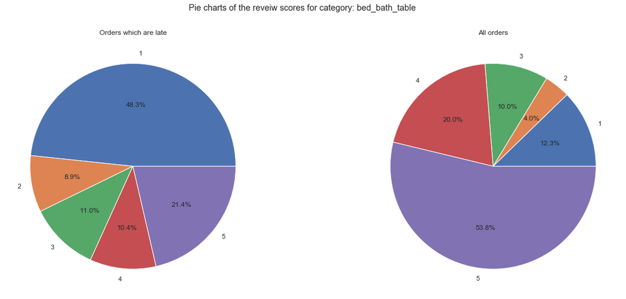

```
Mean review score of late orders 2.4758961681087763
Mean review score for all order 3.9893362350380848
30.887258172114745 % of bad reviews were also late, which is 463 orders
```

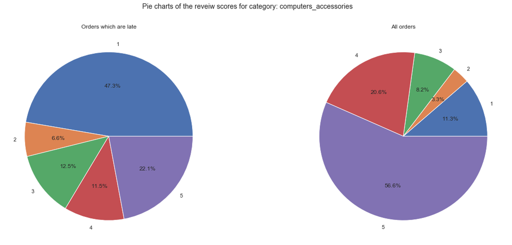

```
Mean review score of late orders 2.5447316103379722
Mean review score for all order 4.078223451667435
28.52631578947368 % of bad reviews were also late, which is 271 orders
```

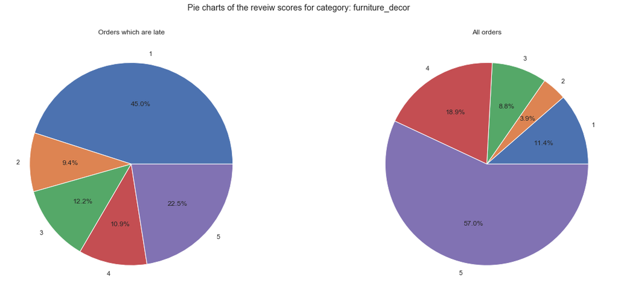

```
Mean review score of late orders 2.5647279549718576
Mean review score for all order 4.06023514253503
30.398322851153043 % of bad reviews were also late, which is 290 orders
```

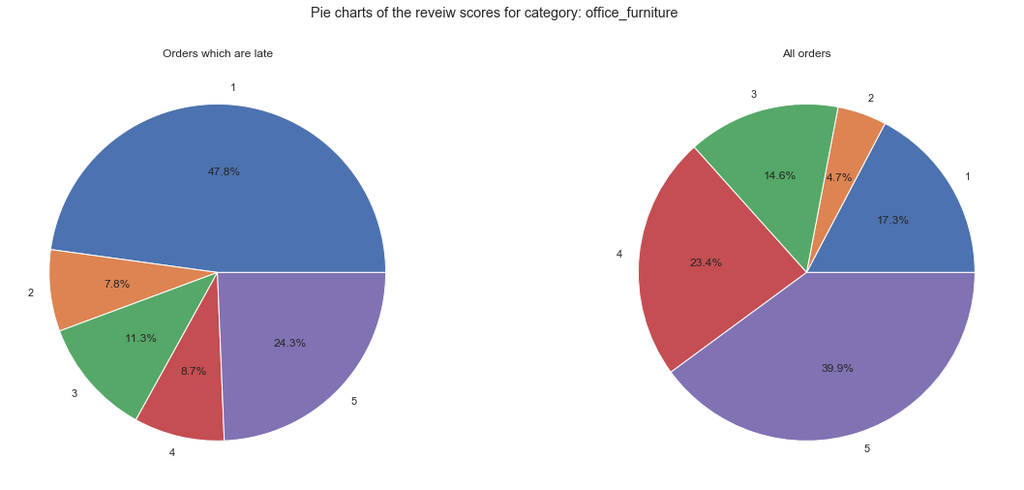

```
Mean review score of late orders 2.5391304347826087
Mean review score for all order 3.64
23.272727272727273 % of bad reviews were also late, which is 64 orders
```

```python
labels = '1', '2', '3', '4', '5'

for i in range(0,len(categories)):
    sns.set(rc={'figure.figsize':(20, 8)})
    temp1 = df_category_late[df_category_late['product_category_name_eng'] == categories[i]]
    temp2 = df[df['product_category_name_eng'] == categories[i]]
    sizes1 = temp1.groupby(['review_score']).count()['product_id']
    sizes2 = temp2.groupby(['review_score']).count()['product_id']

    fig, (ax1,ax2) = plt.subplots(1,2)
    fig.suptitle('Pie charts of the reveiw scores for category: {}'.format(categories[i]))
    ax1.pie(sizes1, labels=labels, autopct='%1.1f%%')
    ax2.pie(sizes2, labels=labels, autopct='%1.1f%%')
    ax1.set_title('Orders which are late')
    ax2.set_title('All orders')
    plt.show()

    print('Mean review score of late orders',temp1['review_score'].mean())
    print('Mean review score for all order', temp2['review_score'].mean())
    print((sum(sizes1[0:2])/sum(sizes2[0:2]))*100,
          '% of bad reviews were also late, which is',sum(sizes1[0:2]),'orders')
```

In the pie charts above it becomes clear that for the orders which are late the distribution is very different than for the pie charts with all the observations. In the pie charts with only late observations the review score of 1 is by far the biggest chunck, and the bad review scores (score of 1 or 2) makes up more than 50% of the scores.

This clearly illustrates that it is important that an order is on time as around 1/3 of the bad reviews for the selected categories and overall were also late orders. By investing in making the orders on time 1/3 of the bad reviews could potentially be changed to good reviews, thus lowering the amount of bad reviews.

We will now further look at the late deliveries by exploring the amount of days a late delivery is delayed with. Therefor a new column `delayed` is added. A negativ number indicates that the order arrived before time and a positiv number indicates a delay. To simplify we are only looking at days, thereby a order which is only hours late will get the value of 0.

```python
df['delayed']=(df['order_delivered_customer_date']-df['order_estimated_delivery_date']).dt.days
df['delayed'].head()
```

```
0   -12
1    -6
2    -7
3    -2
4   -13
Name: delayed, dtype: int64
```

```python
print("---------- On time --------- \n",df[df['late'] == 0].describe()['delayed'], "\n")
print("---------- Late ---------- \n",df[df['late'] == 1].describe()['delayed'])
```

```
---------- On time ---------
 count    87436.000000
mean       -13.714420
std          7.378177
min       -147.000000
25%        -18.000000
50%        -13.000000
75%         -9.000000
max         -1.000000
Name: delayed, dtype: float64

---------- Late ----------
 count    7708.000000
mean        8.871303
std        13.933056
min         0.000000
25%         1.000000
50%         5.000000
75%        11.000000
max       188.000000
Name: delayed, dtype: float64
```

We see that on average on time orders arrive 13.7 days before time and that late orders arrive with 8.9 days delayed. We do however also see that some orders arrived 147 days before estimated arrival date and that some order arrived 188 days late. This seems like some very extreme early and late orders, which could indicate that maybe Olist also have some problems with the estimation of the delivery date.

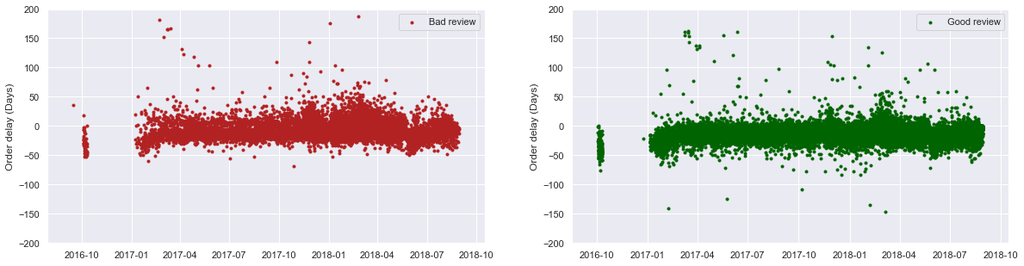

```python
fig, (ax1, ax2) = plt.subplots(1,2,figsize=(20,5))
ax1.scatter(df[df['bad_reviews'] == 1]['order_purchase_timestamp'], df[df['bad_reviews'] == 1]['delayed'],
           label = "Bad review", c = 'firebrick', marker = '.')
ax1.legend()
ax1.set_ylabel("Order delay (Days)")
ax1.axes.set_ylim(-200,200)
ax2.scatter(df[df['bad_reviews'] == 0]['order_purchase_timestamp'], df[df['bad_reviews'] == 0]['delayed'],
           label = "Good review", c = 'darkgreen', marker = '.')
ax2.legend()
ax2.set_ylabel("Order delay (Days)")
ax2.axes.set_ylim(-200,200)
plt.show()
```

The plot above shows the amount of days each orders is delayed/before time, the left plot show the bad reviews and the right plot shows the good reviews. It can be seen that the good reviews are centered between -50 and 0 while the bad reviews are in between -50 and 50. We do also see good reviews which were also late, this makes sense accordingly to the distribution of the review scores for the late orders as 50% bad reviews were bad reivews. We also see many bad reviews which are not late, indicating that orders which are on time of course also are prone to bad reviews. However, the two plots strongly backup that generally an order will get a bad reviews if it is late.

## Analysing the review comments

This section will analysie the review comments by using TF-IDF and topic modelling. The 4 time periods specified earlier will be analysed by both TF-IDF and topic modelling to see if any specific issues can be found within these time periods. Herafter all reviews will be analysed by topic modeling to find general problems and lastly the reviews for the choosen product categories are analysed.

Not all orders which has a review score also has a review comment. Therefor a new dataframe `df_rev` is made which only has orders with review comments.

```python
# Filter away all observations which does not have a review_comment_message
df_rev = df_datetime.dropna(subset=['review_comment_message'])
print(df_datetime.shape)
print(df_rev.shape)
print(df_datetime.shape[0]-df_rev.shape[0])
print(df_rev.shape[0]/df_datetime.shape[0]*100)
```

```
(97277, 14)
(40417, 14)
56860
41.54836189438408
```

The dataframe has thus been reduced from 97277 orders to only 40417 orders due to lacking review comments. Thereby 56860 orders which have a review score but do not have review comments have been removed and only 41% of the dataframe is left. Lets look at the overall distribtion of the review scores for the orders which have review comments.

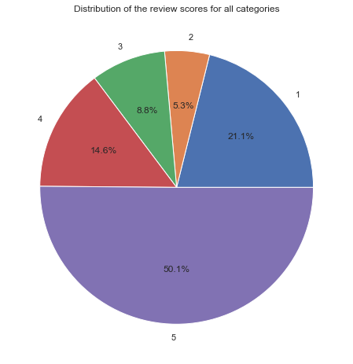

```
26.41215330182844 % of the ratings are bad reviews
Mean review score: 3.6734789816166464
```

```python
size = df_rev.groupby(['review_score']).count()['order_id']
labels = size.index
plt.pie(size,labels=labels,autopct='%1.1f%%')
plt.title("Distribution of the review scores for all categories")
plt.show()
print(sum(size[0:2]) / sum(size)*100,'% of the ratings are bad reviews')
print('Mean review score:',df_rev['review_score'].mean())
```

The distribution of scores for the orders which gave reviews are very different than for all orders. We see that 26% of the reviews are bad which is much higher compared to the 13% for all orders. The mean review score is only 3.7 which is a similar mean score to some of the lowest mean scores for the product categories. This results intuitively makes sense as angry customers probably are more likely to write a review.

To further understand the review comments lets look at their lengths.

```python
# Compute the average length of reviews.
average_len = []
for i in range(1,6):
    average_len.append(df_rev[df_rev['review_score'] == i]['review_comment_message'].str.len().mean())
```

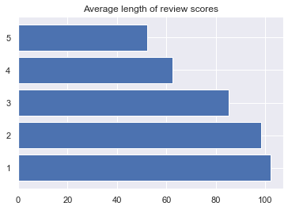

```python
names = ['1','2','3','4','5']

sns.set(rc={'figure.figsize':(6,4)})
plt.barh(names,average_len)
plt.title("Average length of review scores")
plt.show()
```

As the review score decreases the review comments becomes larger. This again makes sense intuitively as angry customers generally will have more things to say about their experience.

In order to translate the review comments later we will have to remove punctuations, make letters lower case and remove any symboles. This is done before the data is split. To do this a definition from lecture 2 of the course is changed and customized for this purpose.

```python
import string
import re

## Definition for removing punctiations and making all letter lower case
def text_processing(text):
    ## Remove the punctiation
    text = "".join([c for c in text
                    if c not in string.punctuation])

    ## lower case
    text = "".join([c.lower() for c in text])

    ## Removing symbols
    text = re.sub(r'[^\w]', ' ', text)

    return text
```

```python
df_rev['review_comment_message'] = df_rev['review_comment_message'].apply(text_processing)
df_rev.head()
```

| order_purchase_timestamp | product_category_name | review_score | review_comment_message | order_id | customer_unique_id | customer_id | order_delivered_customer_date | price | product_id | order_estimated_delivery_date | order_purchase_timestamp | product_category_name_eng | bad_reviews | is_order |
| --- | --- | --- | --- | --- | --- | --- | --- | --- | --- | --- | --- | --- | --- | --- |
| 2018-04-24 16:16:53 | perfumaria | 5 | super adooorei o delineador ele é bem preto e ... | e17e4f88e31525f7deef66779844ddce | b1a1199364a4a7fe27c4486ab63f550d | f8a3e963a310aa58b60a5b1fed5bceb5 | 2018-04-27 16:42:17 | 10.91 | 1e9e8ef04dbcff4541ed26657ea517e5 | 2018-05-09 00:00:00 | 2018-04-24 16:16:53 | perfumery | 0 | 1 |
| 2018-01-31 18:55:36 | artes | 5 | excelente apontador em 3 segundos uma ponta pe... | 5236307716393b7114b53ee991f36956 | 4b86049cb99e4aa774031daa9cd18f18 | 03fc97548af8f58fefc768d12b546c9c | 2018-02-16 13:27:08 | 248.00 | 3aa071139cb16b67ca9e5dea641aaa2f | 2018-02-22 00:00:00 | 2018-01-31 18:55:36 | art | 0 | 1 |
| 2018-08-03 08:55:50 | bebes | 1 | modelo comprado travesseiro memoria carinho ba... | 143d00a4f2dde4e0364ee1821577adb3 | 619e926d09b26efbd5180368b1ddc874 | 322162b5ca010c2b059cb5224dd818b1 | 2018-08-06 15:14:32 | 112.30 | cef67bcfe19066a932b7673e239eb23d | 2018-08-08 00:00:00 | 2018-08-03 08:55:50 | baby | 1 | 1 |
| 2018-01-14 12:31:15 | cool_stuff | 2 | veio faltando o bebê conforto | 9632facd8bd95315d63a23bf616d85b0 | f7495a8d48d05ca657eb075b905a1b8b | 7e395b4bf53aea8c56b1213f1b801411 | 2018-01-19 22:39:01 | 958.00 | 732bd381ad09e530fe0a5f457d81becb | 2018-02-07 00:00:00 | 2018-01-14 12:31:15 | cool_stuff | 1 | 1 |
| 2017-11-24 14:22:48 | moveis_decoracao | 2 | na entrega veio faltando os dois assento futon... | 6ecf7023e8dd4ec8b08746c35b9fcb60 | 8fe54925e8ff1067c803ae7026fe384b | 181e2217f874cb5390be37f378db5e07 | 2017-12-07 09:38:30 | 9.99 | 2548af3e6e77a690cf3eb6368e9ab61e | 2017-12-19 00:00:00 | 2017-11-24 14:22:48 | furniture_decor | 1 | 1 |

The data is now split by using the dates described and found in section VII.

```python
# Dataframe containing black friday
bf = df_rev[bf_start:bf_end]
# Dataframe containing the period with high amount the review score of 1
rev1_high = df_rev[rev1W_start:rev1W_end]
# Dateframes containing the baseline days.
normalW1 = df_rev[normalW1_start:normalW1_end]
normalW2 = df_rev[normalW2_start:normalW2_end]
print(bf.shape)
print(rev1_high.shape)
print(normalW1.shape)
print(normalW2.shape)
```

```
(682, 14)
(741, 14)
(417, 14)
(2914, 14)
```

The reviews are however still in portugese. To translate the reviews to english the `Translator` from `googletrans` is used. Google translate has a limit on the maximum amount of characters which can be translated every day which means that it is not possible to translate all reviews. The amount of reviews are therefor kept very low to be able to translate reviews from the different dataframes. The translated reviews are furthermore saved and loaded after translation to avoid long running times. These translated reviews will be used for making word clouds and some text analysis.

However, when doing text analysis it is desirable to have as many reviews as possible. To be able to use all reviews the portugese review comments are also saved for data analysis as the result of these hereafter can be translated to english.

The dataframes are further split in good and bad reviews when doing TF-IDF analysis to be able to spot spefic negativ words.

```python
from googletrans import Translator
translator = Translator()
```

### Black friday reviews

Initially we need to see if we have enough good and bad reviews in this time period.

```python
bf.groupby(['bad_reviews']).count()['review_score']
```

```
bad_reviews
0    418
1    264
Name: review_score, dtype: int64
```

For the reviews which are translated, only 100 good and bad reviews are choosen. We further want to make sure that there are no dependency of the order so the 100 observations are choosen randomly.

```python
# Choose the good reviews
bf_good_por = bf[bf['bad_reviews'] == 0]
bf_good = bf_good_por.sample(n=100, random_state=42)
print(bf_good.shape)

# Choose the bad reveiws
bf_bad_por = bf[bf['bad_reviews'] == 1]
bf_bad = bf_bad_por.sample(n=100, random_state=42)
print(bf_bad.shape)
```

```
(100, 14)
(100, 14)
```

#### Translating and text editing

With the dataframes ready we can start using the translator. To be sure that the reviews are being translated from Portoguese to English we have to define the source language, `src = 'pt'`, and the destination language `dest = 'en'`. The language codes can be found by typing `print(googletrans.LANGUAGES)`.

As we have to translate from several dataframes the definition `translation(dataframe_name)` is made.

```python
def translation(dataframe_name):
    # Create empty column for the translated reviews
    dataframe_name['review_comment_message_eng'] = ''

    for i in range(0,len(dataframe_name)):
        temp = translator.translate(dataframe_name['review_comment_message'][i], src='pt',dest='en').text
        dataframe_name['review_comment_message_eng'][i] = temp

    return dataframe_name
```

```python
# Translating the bf_bad
# translation(bf_bad)

# Save to csv file
# bf_bad.to_csv(r'C:\Users\Andreas Kaae\Documents\DTU\8. semester (Start kandidat)\Advanced Business Analytics\Final project\data\bf_bad.csv')

# Load csv file
bf_bad = pd.read_csv('data/bf_bad.csv')

# Reset index
bf_bad = bf_bad.set_index('order_purchase_timestamp')
bf_bad.head()
```

| order_purchase_timestamp | product_category_name | review_score | review_comment_message | order_id | customer_unique_id | customer_id | order_delivered_customer_date | price | product_id | order_estimated_delivery_date | order_purchase_timestamp.1 | product_category_name_eng | bad_reviews | is_order | review_comment_message_eng |
| --- | --- | --- | --- | --- | --- | --- | --- | --- | --- | --- | --- | --- | --- | --- | --- |
| 2017-11-22 11:42:43 | audio | 2 | paguei pelo produto e não chegou na data prevista | 9b643bf8a8614206d936530d416aef57 | 5995c21133c9ac12c6da5253daf5b40c | e1b64e8d881811f9914cc891ab48ee89 | 2017-12-19 16:04:42 | 19.90 | 7c4a8bec217df1de0df2b5aaf8175b65 | 2017-12-11 00:00:00 | 2017-11-22 11:42:43 | audio | 1 | 1 | I paid for the product and did not arrive on time |
| 2017-11-24 11:42:09 | eletronicos | 1 | bandeja não é estável é presa apenas por um ún... | b048658d074ad2c4863ea7021ddfe990 | 52e05f52b2ccd1945aafaae6ceff7ba1 | a2618f04f2eb07c068682d871cf7f5d9 | 2017-12-01 13:38:39 | 189.90 | 6ab6d9589ae19abcee458918d4779fae | 2017-12-12 00:00:00 | 2017-11-24 11:42:09 | electronics | 1 | 1 | is not stable tray is secured by a single cent... |
| 2017-11-23 00:09:51 | relogios_presentes | 1 | péssimo entrei por diversas vezes contato por... | b084d12a7e70bcabb8998f113f04e601 | 36cbfc807689e6396e4b115c72f976a3 | 89a762414f228621ebf73186df0aabed | 2017-12-16 18:15:56 | 190.83 | c5b72065154ec27c2d1ed8a654c3348f | 2017-12-14 00:00:00 | 2017-11-23 00:09:51 | watches_gifts | 1 | 1 | lousy entered several times by phone contact a... |
| 2017-11-23 22:56:37 | ferramentas_jardim | 1 | comprei 2 luminárias e chegou apenas uma agu... | 84e4486c820db46414cbfb1dbbe80889 | fdbc9e3e8ff4d5fa66c92c652912aef4 | 93a76cec9665317ca677f7800987b681 | 2017-12-02 17:28:52 | 49.00 | 389d119b48cf3043d311335e499d9c6b | 2017-12-14 00:00:00 | 2017-11-23 22:56:37 | garden_tools | 1 | 1 | I bought two fixtures and only got one waiting... |
| 2017-11-23 13:35:20 | relogios_presentes | 2 | aguardando posição sobre o produto | b8b6924f004e191923963e8ab1655ed9 | a91ca5a84835eabaf3fc6846aa792e1b | 53c00128b4cdd554611efd233859dd88 | 2017-12-20 20:38:46 | 170.00 | e0d64dcfaa3b6db5c54ca298ae101d05 | 2017-12-18 00:00:00 | 2017-11-23 13:35:20 | watches_gifts | 1 | 1 | waiting position on the product |

With the messages translated we now need to remove the stop words as these does not tell us anything about the actual content of a review. This is done by using the defitition `remove_stopwords_eng(text)`.

```python
## Import stop words
from sklearn.feature_extraction import stop_words

## Define a defeinition for removing stopwords
def remove_stopwords_eng(text):
    # remove stopwords
    text = " ".join([w for w in text.split()
                    if w not in stop_words.ENGLISH_STOP_WORDS])
    return text
```

Another defintion, `remove_stopwords_por(text)` is made for the exact same purpose but for the portuguese reviews. To remove the portuguese stop words `stopwords` from `nltk.corpus` is imported. To enable the use of portuguese stop words installations are needed. To do this first write `import nltk` and then write `nltk.download()` whereafter a new window should open. Under 'Corpora' the identifier 'stopwords' needs to be downloaded.

```python
## Define a defeinition for cleaning the text
from nltk.corpus import stopwords

def remove_stopwords_por(text):
    # remove stopwords
    text = " ".join([w for w in text.split()
                    if w not in stopwords.words('portuguese')])
    return text
```

We can now apply the defitions to the english and portuguese reviews. The dataframe `df_bad_por` is used for the bad reveiws as this contains all reviews within the timeframe.

```python
bf_bad['review_comment_message_eng'] = bf_bad['review_comment_message_eng'].apply(remove_stopwords_eng)
bf_bad_por['review_comment_message'] = bf_bad_por['review_comment_message'].apply(remove_stopwords_por)
```

The translated reviews are now ready for text analysis.

The same procedure as performed on `bf_bad` is preformed on `bf_good`.

**`bf_good`**

While trying to translate the `bf_good` dataframe it was found that the row with timestamp '2017-11-24 19:51:23' had an entry which could not be translated. This row is therefor removed before translation.

```python
temp = bf_good['review_comment_message'][12:13]
bf_good['review_comment_message'][12:13].replace(temp,np.nan,inplace=True)
bf_good.dropna(subset=['review_comment_message']).head()
```

| order_purchase_timestamp | product_category_name | review_score | review_comment_message | order_id | customer_unique_id | customer_id | order_delivered_customer_date | price | product_id | order_estimated_delivery_date | order_purchase_timestamp | product_category_name_eng | bad_reviews | is_order |
| --- | --- | --- | --- | --- | --- | --- | --- | --- | --- | --- | --- | --- | --- | --- |
| 2017-11-23 15:05:54 | cama_mesa_banho | 5 | o produto é muito bom de boa qualidade e muito... | d0bff47153ef056bb4f884a2ec2f0691 | 7305430719d715992b00be82af4a6aa8 | 5bbd3f38fe696e4bc73a9f914a6716e6 | 2017-12-05 00:37:37 | 39.5 | 553e0e7590d3116a072507a3635d2877 | 2017-12-20 00:00:00 | 2017-11-23 15:05:54 | bed_bath_table | 0 | 1 |
| 2017-11-22 18:13:26 | moveis_cozinha_area_de_servico_jantar_e_jardim | 4 | produto chegou no prazo muito bom | cad5d696e0d7bf7f475ff4cb616e7cd1 | 8d159ebbb559405a89dca5384fe9d727 | a32b503a5a6817541a8e09d6c70f9642 | 2017-12-14 18:16:54 | 409.0 | 961930544d39899c18cfdbc336aeb15e | 2017-12-19 00:00:00 | 2017-11-22 18:13:26 | kitchen_dining_laundry_garden_furniture | 0 | 1 |
| 2017-11-23 15:00:28 | brinquedos | 5 | bom produto chegou dentro do prazo eu recomendo | 7f2810de522b451a990407ada69ff9d0 | 8f5784632f328f341d2cb58cb2c5f933 | 05a4b790359862d814b2f6d69e4e9f9f | 2017-11-30 17:56:42 | 129.8 | 23bcd6822a33df5534f9b290216eec1f | 2017-12-15 00:00:00 | 2017-11-23 15:00:28 | toys | 0 | 1 |
| 2017-11-24 23:39:51 | ferramentas_jardim | 5 | parabéns | 32e839df202e265a92fc882a73aca02f | c5ae8dc077209a38cc64ba830ac26bbd | 68f99cdb70a1deda1e1e9b2c4f591987 | 2017-12-07 15:22:23 | 49.0 | 368c6c730842d78016ad823897a372db | 2017-12-14 00:00:00 | 2017-11-24 23:39:51 | garden_tools | 0 | 1 |
| 2017-11-24 22:04:33 | cama_mesa_banho | 5 | rapido e bem embalado | 22e06cbdd9638e481433e910bdd56d40 | 432bbaee2b6efe0f52cc5fbe03c6074e | 040823cb5374775c7c43e8e33fc5016a | 2017-11-28 22:32:36 | 35.9 | ff7c7524d5f9a8386ab27088ec03c1fb | 2017-12-08 00:00:00 | 2017-11-24 22:04:33 | bed_bath_table | 0 | 1 |

The review comments in the dataframe can now be translated.

```python
# Translating bf_good
# translation(bf_good)

# # Saving to csv file
# bf_good.to_csv(r'C:\Users\Andreas Kaae\Documents\DTU\8. semester (Start kandidat)\Advanced Business Analytics\Final project\data\bf_good.csv')

# Loading the csv file
bf_good = pd.read_csv('data/bf_good.csv')

# Removing stop words
bf_good['review_comment_message_eng'] = bf_good['review_comment_message_eng'].apply(remove_stopwords_eng)

# Reset index
bf_good = bf_good.set_index('order_purchase_timestamp')
bf_good.head()
```

| order_purchase_timestamp | product_category_name | review_score | review_comment_message | order_id | customer_unique_id | customer_id | order_delivered_customer_date | price | product_id | order_estimated_delivery_date | order_purchase_timestamp.1 | product_category_name_eng | bad_reviews | is_order | review_comment_message_eng |
| --- | --- | --- | --- | --- | --- | --- | --- | --- | --- | --- | --- | --- | --- | --- | --- |
| 2017-11-23 15:05:54 | cama_mesa_banho | 5 | o produto é muito bom de boa qualidade e muito... | d0bff47153ef056bb4f884a2ec2f0691 | 7305430719d715992b00be82af4a6aa8 | 5bbd3f38fe696e4bc73a9f914a6716e6 | 2017-12-05 00:37:37 | 39.5 | 553e0e7590d3116a072507a3635d2877 | 2017-12-20 00:00:00 | 2017-11-23 15:05:54 | bed_bath_table | 0 | 1 | product good quality liked |
| 2017-11-22 18:13:26 | moveis_cozinha_area_de_servico_jantar_e_jardim | 4 | produto chegou no prazo muito bom | cad5d696e0d7bf7f475ff4cb616e7cd1 | 8d159ebbb559405a89dca5384fe9d727 | a32b503a5a6817541a8e09d6c70f9642 | 2017-12-14 18:16:54 | 409.0 | 961930544d39899c18cfdbc336aeb15e | 2017-12-19 00:00:00 | 2017-11-22 18:13:26 | kitchen_dining_laundry_garden_furniture | 0 | 1 | product arrived good time |
| 2017-11-23 15:00:28 | brinquedos | 5 | bom produto chegou dentro do prazo eu recomendo | 7f2810de522b451a990407ada69ff9d0 | 8f5784632f328f341d2cb58cb2c5f933 | 05a4b790359862d814b2f6d69e4e9f9f | 2017-11-30 17:56:42 | 129.8 | 23bcd6822a33df5534f9b290216eec1f | 2017-12-15 00:00:00 | 2017-11-23 15:00:28 | toys | 0 | 1 | good product arrived time I recommend |
| 2017-11-24 23:39:51 | ferramentas_jardim | 5 | parabéns | 32e839df202e265a92fc882a73aca02f | c5ae8dc077209a38cc64ba830ac26bbd | 68f99cdb70a1deda1e1e9b2c4f591987 | 2017-12-07 15:22:23 | 49.0 | 368c6c730842d78016ad823897a372db | 2017-12-14 00:00:00 | 2017-11-24 23:39:51 | garden_tools | 0 | 1 | congratulations |
| 2017-11-24 22:04:33 | cama_mesa_banho | 5 | rapido e bem embalado | 22e06cbdd9638e481433e910bdd56d40 | 432bbaee2b6efe0f52cc5fbe03c6074e | 040823cb5374775c7c43e8e33fc5016a | 2017-11-28 22:32:36 | 35.9 | ff7c7524d5f9a8386ab27088ec03c1fb | 2017-12-08 00:00:00 | 2017-11-24 22:04:33 | bed_bath_table | 0 | 1 | fast packed |

Stop words are also removed from all the portugese reviews.

```python
# Process the portuguese reviews
bf_good_por['review_comment_message'] = bf_good_por['review_comment_message'].apply(remove_stopwords_por)
```

The reviews have been translated and both english and portugese reviews have gone through text processing.

#### Text analysis

To get an overview of all of the translated reviews they are plotted together in a wordcloud to understand what words are most common. To do this the package `wordcloud` is used together with the defitnition `show_wordcloud(data, title)` which is taken from lecture 2 and changed for this assignment.

```python
import wordcloud

def show_wordcloud(data, title):
    text = ' '.join(data.astype(str).tolist())
    stopwords = set(wordcloud.STOPWORDS)

    fig_wordcloud = wordcloud.WordCloud(stopwords=stopwords,
        max_font_size=100, max_words=100, background_color="white").generate(text)

    plt.figure(figsize=(10,7), frameon=True)
    plt.imshow(fig_wordcloud, interpolation="bilinear")
    plt.axis('off')
    plt.title(title, fontsize=20)
    plt.show()
```

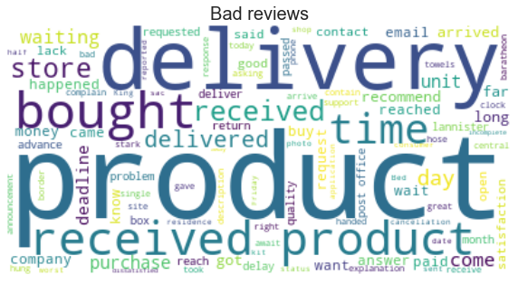

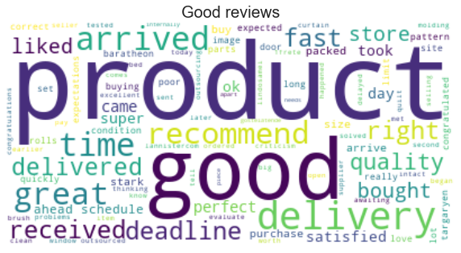

```python
show_wordcloud(bf_bad['review_comment_message_eng'],'Bad reviews')
show_wordcloud(bf_good['review_comment_message_eng'],'Good reviews')
```

From the wordclouds for the good reviews we see many positive words suchs as *recommend*, *good*, *liked*, *great*, *fast* etc. From the wordcloud for the bad reviews only few words are directly negative such as *waiting* and we even see positive words such as *recommend*. In both wordclouds we further have many words which are neutral such as *product* and *delivery*. The problems is further that many words we simply do not know whether or not are negative or positive as it will depend on the context. It is therefor clear that we need to include more than one word to get any real insights from the reviews.

**TF-IDF - Term frequency - inverse document frequency**

To get a better understanding of which words are most common in the reviews a TF-IDF analysis will be performed. The idea of the TF-IDF is that it penalises the frequent words and increase importance of rare words. To do this the `TfidVectorizer` from `sklearn.feature_extraction.text` is used.

```python
# Import packages for analysing text
from sklearn.feature_extraction.text import TfidfVectorizer
```

To simplify the work with making a TF-IDF analysis a definition for analysing the english reviews `tfidf_analyse` is constructed and one for analysing the portuguese reviews `tfidf_analyse_por`. In the definition for analysing the portuguese reviews the Xth most common words are also traslated. Both definitions needs the name of the dataframe `dataframe_name` and the lower (`ngram_range1`) and upper (`ngram_range2`) bound of the range of n-values for different n-grams to be extracted. The difinition for the portuguese reviews further takes `X` which is the amount of n first words to be translated.

```python
def tfidf_analyse(dataframe_name,ngram_range1,ngram_range2):
    # Set the tfidf vectorizer
    tfidf_vectorizer=TfidfVectorizer(use_idf=True, ngram_range
                                     = (ngram_range1,ngram_range2))

    #Fit the TfidfVectorizer
    tfidf_vectorizer_vectors = tfidf_vectorizer.fit_transform(
                                dataframe_name['review_comment_message_eng'].values)

    # Compute the mean of the tfidf scores for all the reviews
    mean_tfidf = sum(tfidf_vectorizer_vectors[:]).T.todense()/dataframe_name.shape[0]

    # Place the scores in a pandas dataframe and sort by value
    temp = pd.DataFrame(mean_tfidf, index=tfidf_vectorizer.get_feature_names(),
                        columns=["tf-idf"])
    temp = temp.sort_values(by=["tf-idf"],ascending=False)

    # Return the dataframe
    return temp
```

```python
def tfidf_analyse_por(dataframe_name, X,ngram_range1,ngram_range2):
    # Set the tfidf vectorizer
    tfidf_vectorizer=TfidfVectorizer(use_idf=True, ngram_range
                                     = (ngram_range1,ngram_range2))

    #Fit the TfidfVectorizer
    tfidf_vectorizer_vectors = tfidf_vectorizer.fit_transform(
                               dataframe_name['review_comment_message'].values)


    # Compute the mean of the tfidf scores for all the reviews
    mean_tfidf = sum(tfidf_vectorizer_vectors[:]).T.todense()/dataframe_name.shape[0]

    # Place the scores in a pandas dataframe and sort by value
    temp = pd.DataFrame(mean_tfidf, index=tfidf_vectorizer.get_feature_names(),
                        columns=["tf-idf"])
    temp = temp.sort_values(by=["tf-idf"],ascending=False)

    # Translate the Xth first words
    temp['Translation'] = ' '

    for i in range(0,X):
        trans = translator.translate(temp.index[i], src='pt',dest='en').text
        temp['Translation'][i] = trans

    # Return the dataframe
    return temp
```

Apply the TF-IDF on the english reviews. Here we choose to look at any combinations of words from 2 to 5 words.

```python
print("bf_bad \n", tfidf_analyse(bf_bad,2,5)[0:20])
print('-'*50)
print("bf_good \n",tfidf_analyse(bf_good,2,5)[0:20])
```

```
bf_bad
                           tf-idf
received product        0.036534
product arrived         0.022331
product delivered       0.016659
product does            0.010354
faster delivery         0.010000
long wait               0.010000
judge received          0.010000
received application    0.010000
waiting product         0.010000
desired product         0.010000
wonder deliver          0.010000
received received       0.010000
product did             0.008490
we received             0.006449
we received product     0.006449
does work               0.006043
product does work       0.006043
toners working          0.005774
towels received         0.005774
trouble toners working  0.005774
--------------------------------------------------
bf_good
                       tf-idf
product arrived     0.018687
good quality        0.016353
fast delivery       0.016300
delivery right      0.011784
product delivered   0.011583
right time          0.010776
like product        0.010101
fast packed         0.010101
time limit          0.010101
pleased purchase    0.010101
really enjoyed      0.010101
they congratulated  0.010101
excellent product   0.010101
td ok               0.010101
recommend good      0.010101
great product       0.009661
ahead schedule      0.009493
arrived time        0.009149
good product        0.009125
delivered time      0.008811
```

Apply the TF-IDF on the portugese reveiws.

```python
X = 20
print("bf_bad_por \n", tfidf_analyse_por(bf_bad_por, X,2,5)[0:X])
print('-'*50)
print("bf_good_por \n",tfidf_analyse_por(bf_good_por, X,2,5)[0:X])
```

```
bf_bad_por
                           tf-idf                    Translation
recebi produto          0.028214               received product
ainda recebi            0.011310                 yet I received
produto chegou          0.010202                product arrived
produto entregue        0.008622              product delivered
ainda recebi produto    0.008202             I received product
produto ainda           0.006777                    product yet
nao recebi              0.006774                   not received
aguardando produto      0.006591               awaiting product
nao recebi produto      0.006583  I did not recieve the product
prazo entrega           0.004886                  term delivery
pedido chegou           0.004743                  order arrived
produto defeito         0.004394                 product defect
aguardo recebimento     0.004292                  await receipt
produto ainda entregue  0.004180          yet delivered product
ainda entregue          0.004180                  yet delivered
recebi apenas           0.004044                  just received
comprei dois            0.003826                     bought two
recebemos produto       0.003788               received product
problema correios       0.003788                   problem post
esperando entrega       0.003788           waiting for delivery
--------------------------------------------------
```

```
bf_good_por
                               tf-idf                      Translation
antes prazo                 0.017811                  before deadline
bom produto                 0.012506                     good product
chegou antes                0.011340                we arrived before
chegou antes prazo          0.010600       We arrived before deadline
produto chegou              0.010102                  product arrived
produto entregue            0.009235                product delivered
produto bom                 0.008872                     good product
dentro prazo                0.008528                  within deadline
entrega rápida              0.008186                    fast delivery
atendeu expectativas        0.007748                 met expectations
entrega prazo               0.006939                    delivery time
tudo ok                     0.006201                 everything is OK
produto excelente           0.006195                excellent product
tudo certo                  0.005840                        all right
produto qualidade           0.005673                  product quality
entregue antes              0.005497                 delivered before
gostei produto              0.005369                     like product
produto chegou antes        0.005348           product arrived before
produto chegou antes prazo  0.005348  product arrived before deadline
produto bonito              0.005089                beautiful product
```

By comparing the TF-IDF analysis of the 100 tranalated reviews with the analysis on all portuguese reviews within the time frame we see that the the words and the frequencies are different. This is both because the portuguese reviews are translated after being processed and that these words were found using alot more reviews. However by comparing the results for the bad and good reviews overall the reviews are similar, it is therefor decided to not translate any more reviews but to use the portuguese reviews and translate the results of these. This also means that no more word clouds will be printed.

By examining the bad reviews from Black Friday it can be seen that we still have words which are neutral such as *received product* and *product delivered* as we do not know excatly what is referred to here. Other words such as *not received*, *awaiting product* and *waiting for delivery* shows that many customers are complaining because they have not received their product and some are unhappy because they are waiting for their receips *await receipt*. The term *problem post* also appears which idicats a specific problem with the post. Another problem is also with the products as *product defect* appears.

By examining the good reviews from Black Friday customers they are commenting the delivery positively *before deadline*, *within deadline*, *fast delivery*, *delivered before*, *product arrived before deadline*. Customers are also satisfied with the products overall *good product*, *excellent product*, *like prodcut* and even *beautiful product*. So there are clear differences between the good and bad reviews.

**Topic modelling using LDA - Latent Dirichlet Allocation**  
To further understand and analyze specific problems topic modelling is also performed to discover *'topics'* which are in the reviews. To this `CountVectorizer` is used to construct a bag-of-words and `LatentDirichletAllocation` from sklearn.

```python
from sklearn.feature_extraction.text import CountVectorizer
from sklearn.decomposition import LatentDirichletAllocation
```

Two defintions are therefor constructed. The defintion `print_top_words` is inspired by the definition with the same name from lecture 2 but is customized to return the translated result. This definition is used in another definition `topic_model` which takes `data_frame`, `ngram_range1` and `ngram_range2` which does the same as in the defintions for doing TF-IDF. The definition further take `n_components` which specifies the amount of topics and `n_top` which is the amount of top words to print.

```python
def print_top_words(model, feature_names, n_top_words):
    norm = model.components_.sum(axis=1)[:, np.newaxis]
    for topic_idx, topic in enumerate(model.components_):
        #Define empty vectors
        feat_names = []
        feat_names_trans = []
        print(80 * "-")
        print("Topic {}".format(topic_idx))
        for i in topic.argsort()[:-n_top_words - 1:-1]:
            #Append the names and their values
            feat_names.append(feature_names[i])
            feat_values.append(topic[i] / norm[topic_idx][0])
        #Translate
        for i in range(0,len(feat_names)):
            feat_names_trans.append(translator.translate(feat_names[i], src='pt',dest='en').text)
        #Print
        for i in range(0,n_top_words):
            print(round(feat_values[i],4),
                  feat_names_trans[i])
```

```python
def topic_model(data_frame, n_components, ngram_range1, ngram_range2, n_top):
    # Specify LDA
    LDA = LatentDirichletAllocation(n_components = n_components, random_state = 42)
    # Bag of words
    count_vectorizer=CountVectorizer(ngram_range = (ngram_range1, ngram_range2))
    bow_counts =  count_vectorizer.fit_transform(data_frame['review_comment_message'].values)
    # Fit LDA
    lda_fitted = LDA.fit_transform(bow_counts)

    print("\nTopics in LDA model:")
    counts_feature_names = count_vectorizer.get_feature_names()
    n_top_words = n_top
    print_top_words(LDA, counts_feature_names, n_top_words)
```

When doing topic modelling all the reviews (both good and bad) are given to the model as the model then will figure out certain topics from this. First the topic modelling is applied for ngram_range = (1,2) and for 5 topics. This allows the model to choose both single words and two words. Stop words are also removed.

```python
bf['review_comment_message'] = bf['review_comment_message'].apply(remove_stopwords_por)
```

```python
topic_model(bf,5,1,2,10)
```

```
Topics in LDA model:
--------------------------------------------------------------------------------
Topic 0
0.036 product
0.022 term
0.018 good
0.015 before
0.014 has arrived
0.012 before deadline
0.009 delivered
0.008 I received
0.008 delivery
0.007 came
--------------------------------------------------------------------------------
Topic 1
0.011 product
0.011 term
0.008 delivery
0.006 day
0.004 I received
0.003 delivered
0.003 for
0.003 site
0.003 company
0.003 came
--------------------------------------------------------------------------------
Topic 2
0.022 product
0.008 I received
0.008 delivery
0.007 term
0.007 has arrived
0.007 I bought
0.005 still
0.003 products
0.003 not
0.003 purchase
--------------------------------------------------------------------------------
Topic 3
0.021 product
0.009 I bought
0.008 I received
0.008 delivery
0.007 has arrived
0.006 I recommend
0.005 fast
0.005 term
0.004 all
0.004 quality
--------------------------------------------------------------------------------
Topic 4
0.011 product
0.008 I received
0.007 still
0.007 delivery
0.005 order
0.004 delivered
0.004 day
0.004 store
0.004 great
0.003 purchase
```

Topic 0 is about a product which came on time. Topic 3 is also about a product which came on time and further amout that it is recommend, fast and quality. The exact topic of topic 1, 2 and 4 are hard to determine.

### Time period with many reviews of 1

In this section we will look at the period where the review score of 1 was the second most requent review. Initially we see how many good and bad reviews we have.

```python
rev1_high.groupby(['bad_reviews']).count()['review_score']
```

```
bad_reviews
0    413
1    328
Name: review_score, dtype: int64
```

We thus have 413 good and 328 bad reveiws. These reviews are divided in two dataframes.

```python
rev1_bad = rev1_high[rev1_high['bad_reviews'] == 1]
rev1_good = rev1_high[rev1_high['bad_reviews'] == 0]
print(rev1_bad.shape)
print(rev1_good.shape)
```

```
(328, 14)
(413, 14)
```

The reviews need to be processed by removing the stop words.

```python
rev1_bad['review_comment_message'] = rev1_bad['review_comment_message'].apply(remove_stopwords_por)
rev1_good['review_comment_message'] = rev1_good['review_comment_message'].apply(remove_stopwords_por)
```

#### Text analysis

**TF-IDF - Term frequency - inverse document frequency**

```python
X = 20
print("rev1_bad \n", tfidf_analyse_por(rev1_bad, X,2,2)[0:X])
print('-'*50)
print("rev1_good \n",tfidf_analyse_por(rev1_good, X,2,2)[0:X])
```

```
rev1_bad
                       tf-idf           Translation
recebi produto      0.052079      received product
ainda recebi        0.025722        yet I received
produto ainda       0.016445           product yet
produto entregue    0.016309     product delivered
ainda chegou        0.011261              yet come
prazo entrega       0.008412         term delivery
momento recebi      0.007508         received time
nao recebi          0.007218          not received
entrega produto     0.006806      product delivery
produto chegou      0.006029       product arrived
agora recebi        0.006003        now I received
gostaria saber      0.005867  I would like to know
lojas lannister     0.005772      lannister stores
aguardando entrega  0.005656     awaiting delivery
entrega atrasada    0.005282         late delivery
agora nada          0.005276           now nothing
comprei produto     0.005219        bought product
ainda aguardando    0.005167         still waiting
nenhuma satisfação  0.005142       no satisfaction
comprei duas        0.005036            bought two
--------------------------------------------------
```

```
rev1_good
                     tf-idf        Translation
antes prazo       0.024844    before deadline
produto entregue  0.016066  product delivered
bom produto       0.013918       good product
produto bom       0.013821       good product
dentro prazo      0.012953    within deadline
chegou antes      0.012798  we arrived before
recebi produto    0.009575   received product
entrega rápida    0.009560      fast delivery
produto chegou    0.009163    product arrived
produto ótima     0.008261      great product
entrega prazo     0.007772      delivery time
ótimo produto     0.007611      great product
prazo entrega     0.007459      term delivery
entregou prazo    0.007378   delivered within
tudo ok           0.007161   everything is OK
entrega antes     0.006943    before delivery
ótima qualidade   0.006836      great quality
entregue antes    0.006808   delivered before
antes previsto    0.006586     before planned
bem embalado      0.006547        well packed
```

In the bad reviews a similar pattern as for the bad reviews in the Black Friday data is seen. There are alot of terms which are about a order being late or having arrived. More specifically the term *lannister stores* appeares which refers to specific company (remember that companies and partners are replaced with the names of Game of Thrones great houses).

With regards to the good reviews the terms are also very similar to the good reviews in the Black Friday data. Customers are both happy with the delivery and the products.

The reviews are now also analysed with topic modelling. Again for topic modelling the model is given all reviews, therefor the dataframe `rev1_high` is used.

```python
rev1_high['review_comment_message'] = rev1_high['review_comment_message'].apply(remove_stopwords_por)
```

```python
topic_model(rev1_high,5,1,2,10)
```

```
Topics in LDA model:
--------------------------------------------------------------------------------
Topic 0
0.018 product
0.007 has arrived
0.007 delivery
0.007 term
0.006 good
0.006 I received
0.006 I bought
0.004 good
0.004 came
0.004 purchase
--------------------------------------------------------------------------------
Topic 1
0.031 product
0.02 I received
0.014 delivery
0.012 good
0.012 received product
0.011 term
0.01 still
0.007 I recommend
0.006 yet I received
0.006 before
--------------------------------------------------------------------------------
Topic 2
0.032 product
0.012 term
0.011 has arrived
0.01 delivered
0.007 still
0.007 delivery
0.007 product delivered
0.007 I received
0.006 before
0.006 not
--------------------------------------------------------------------------------
Topic 3
0.015 product
0.011 delivery
0.005 delivered
0.004 order
0.004 all
0.004 post offices
0.004 OK
0.003 store
0.003 I bought
0.003 I recommend
--------------------------------------------------------------------------------
Topic 4
0.007 has arrived
0.006 product
0.005 delivery
0.004 products
0.004 I received
0.004 I bought
0.004 still
0.003 term
0.003 already
0.003 purchase
```

From the topics topic 1 and 3 are about recommended products, however in topic 3 it is noticable that the word *post offices* appears. Topic 0, 2 and 4 are about products which has arrived.

### Baseline reviews

We now want to look at the baseline weeks. Again we check how many good and bad reviews we have within the time periods.

```python
normalW1.groupby(['bad_reviews']).count()['review_score']
```

```
bad_reviews
0    332
1     85
Name: review_score, dtype: int64
```

```python
normalW2.groupby(['bad_reviews']).count()['review_score']
```

```
bad_reviews
0    2279
1     635
Name: review_score, dtype: int64
```

As the two dataframes are supposed to be a sort of "baseline" we merge the bad and good reviews from the two dataframes toghether into two new dataframes.

```python
# Choose the good reviews for normalW1
normalW1_good = normalW1[normalW1['bad_reviews'] == 0]

# Choose the bad reveiws for normalW1
normalW1_bad = normalW1[normalW1['bad_reviews'] == 1]

# Choose the good reviews for normalW2
normalW2_good = normalW2[normalW2['bad_reviews'] == 0]

# Choose the bad reveiws for normalW2
normalW2_bad = normalW2[normalW2['bad_reviews'] == 1]

# Merge the good and bad reveiws
normal_good = pd.concat([normalW1_good, normalW2_good])
normal_bad = pd.concat([normalW1_bad, normalW2_bad])
print(normal_good.shape)
print(normal_bad.shape)
```

```
(2611, 14)
(720, 14)
```

We thus have 2611 good reviews and 720 bad reviews for the baseline weeks. As these reviews will not be translated we simply need to remove the stopwords before moving on to text analysis.

```python
normal_good['review_comment_message'] = normal_good['review_comment_message'].apply(remove_stopwords_por)
normal_bad['review_comment_message'] = normal_bad['review_comment_message'].apply(remove_stopwords_por)
```

#### Text analysis

**TF-IDF - Term frequency - inverse document frequency**

```python
X = 20
print("normal_bad \n", tfidf_analyse_por(normal_bad, X, 2,2)[0:X])
print('-'*50)
print("normal_good \n",tfidf_analyse_por(normal_good, X, 2,2)[0:X])
```

```
normal_bad
                      tf-idf        Translation
recebi produto     0.032329   received product
produto veio       0.015796       product came
produto entregue   0.014061  product delivered
ainda recebi       0.009267     yet I received
produto chegou     0.007916    product arrived
produto ainda      0.006953        product yet
nota fiscal        0.006144            invoice
comprei produto    0.005834     bought product
produto comprei    0.005725     product bought
veio defeito       0.005126     It came defect
produto errado     0.004785      wrong product
produto diferente  0.004735  different product
entrega produto    0.004504   product delivery
ainda chegou       0.004495           yet come
nao recebi         0.004099       not received
outro produto      0.004062      other product
paguei frete       0.003892      paid shipping
dentro prazo       0.003789    within deadline
receber produto    0.003713    receive product
dinheiro volta     0.003704         money back
--------------------------------------------------
```

```
normal_good
                      tf-idf        Translation
antes prazo        0.032037    before deadline
chegou antes       0.018456  we arrived before
entrega rápida     0.014225      fast delivery
produto chegou     0.012301    product arrived
ótimo produto      0.011704      great product
produto bom        0.011500       good product
bem antes          0.009761        well before
produto entregue   0.009414  product delivered
dentro prazo       0.009306    within deadline
bom produto        0.009208       good product
chegou bem         0.008709       arrived well
entregue antes     0.008614   delivered before
entrega antes      0.007943    before delivery
tudo certo         0.007878          all right
recebi produto     0.007233   received product
super recomendo    0.006807    super recommend
bem embalado       0.006587        well packed
excelente produto  0.005911  excellent product
ótima qualidade    0.005808      great quality
prazo produto      0.005659       term product
```

By inspecting the terms for the bad reivews we see that for the baseline bad reviews fewer words regarding a late delivery are mentioned, compared to for example in the Black Friday data. However it is intereseting that several words about the product it self is mentioned: *it came defect*, *wrong product*, *other product* and the word *money back* even appers. This indicates that there realtively is a bigger problem with product quality during normal weeks than during for example Black Friday.

When inspecting the good reviews all words are very positive and comments on good, fast and well packed delivery as well as good products with great quality.

The baseline reviews will also be inspected by topic modelling. Therefor the two dataframes `normalW1` and `normalW2` are merged into one dataframe `normalW`.

```python
normalW = pd.concat([normalW1,normalW2])
normalW['review_comment_message'] = normalW['review_comment_message'].apply(remove_stopwords_por)
```

```python
topic_model(normalW,5,1,2,10)
```

```
Topics in LDA model:
--------------------------------------------------------------------------------
Topic 0
0.037 product
0.033 term
0.026 before
0.021 delivery
0.019 before deadline
0.017 has arrived
0.012 good
0.009 I recommend
0.008 delivered
0.008 quality
--------------------------------------------------------------------------------
Topic 1
0.021 product
0.006 has arrived
0.005 came
0.005 still
0.003 I bought
0.003 delivered
0.003 store
0.003 I received
0.002 announced
0.002 according
--------------------------------------------------------------------------------
Topic 2
0.035 product
0.014 I received
0.008 came
0.006 received product
0.006 I bought
0.005 good
0.005 has arrived
0.004 delivery
0.004 date
0.004 still
--------------------------------------------------------------------------------
Topic 3
0.02 good
0.011 I recommend
0.008 product
0.007 great
0.005 liked it
0.004 store
0.003 delivered
0.003 purchase
0.003 I received
0.002 attendance
--------------------------------------------------------------------------------
Topic 4
0.009 product
0.005 great
0.004 I bought
0.004 good
0.004 to be
0.004 delivery
0.003 liked it
0.003 came
0.003 I received
0.002 store
```

All 5 topics from the topic modelling are positive topics which either recommend the product, tell the story about a product on time and that customers likes the product.

Overall the results of the TF-IDF were very similar between the different timeperiods. Terms with regards to problems with late deliveries were present for all periods. It did however appear that deliveries were a bigger problem in the period of Black Friday and the period with many review scores of 1 compared to the baseline. In the baseline there were also several terms regarding defects and wrong products. For the good reviews the terms were very similar for all three time periods, customers were happy with both delivery and the products.

The results for the topics modelling were more unclear but in general most topics were positiv with regards to either the order itself or the delivery. However, for the Black Friday dataset and the dataset with many review scores of 1 it was harder to interpret the topics which might be because of a lower amount of reviews.

### Topic modelling for all reviews

As mentiond before there seemed to be a tendency towards that the topics became more clear with more reviews, therefor topic modelling is also performed on all reviews.

```python
df_rev['review_comment_message'] = df_rev['review_comment_message'].apply(remove_stopwords_por)
```

```python
topic_model(df_rev,5,1,2,10)
```

```
Topics in LDA model:
--------------------------------------------------------------------------------
Topic 0
0.027 I received
0.021 product
0.01 I bought
0.009 received product
0.009 still
0.006 not
0.006 delivered
0.005 day
0.005 only
0.005 liked it
--------------------------------------------------------------------------------
Topic 1
0.017 I recommend
0.013 product
0.011 has arrived
0.009 super
0.008 good
0.008 store
0.007 ever
0.007 before
0.005 fast
0.005 term
--------------------------------------------------------------------------------
Topic 2
0.024 product
0.022 good
0.008 great
0.006 still
0.005 quality
0.005 OK
0.004 I bought
0.004 I recommend
0.003 site
0.003 store
--------------------------------------------------------------------------------
Topic 3
0.016 product
0.011 came
0.007 purchase
0.007 delivery
0.004 great
0.003 note
0.003 order
0.003 product came
0.003 has arrived
0.003 pleased
--------------------------------------------------------------------------------
Topic 4
0.045 product
0.036 term
0.023 before
0.022 delivery
0.018 before deadline
0.015 has arrived
0.012 delivered
0.009 quality
0.009 good
0.008 all
```

**Topic 0:** This topic is unclear as it is about a product which has been received, and is liked but as the word *not* is also present this could be negative.

**Topic 1:** Is a positive topic which tells the story about a product which has arrived fast and that it is recommended.

**Topic 2:** Is also positive topic and is about the product it self.

**Topic 3:** Again positive topic about a product which came and a pleased customer.

**Topic 4:** Also very positive about an order which came before deadline with good quality.

All topics are mainly positive and do not tell us anything specific about the problems.

### Product categories

By analysing the good and bad reviews for the three different time periods general terms about problems were found using TF-IDF. We now want to look at the bad reviews for the choosen product categories as this possibly can give us some key terms about the problems within the categories. To have enough reviews, bad reviews from the whole dataset are gathered.

```python
df_bbt_all = df_rev[df_rev['product_category_name_eng'] == categories[0]]
df_bbt = df_bbt_all[df_bbt_all['bad_reviews'] == 1]
print(df_bbt.shape)

df_ca_all = df_rev[df_rev['product_category_name_eng'] == categories[1]]
df_ca = df_ca_all[df_ca_all['bad_reviews'] == 1]
print(df_ca.shape)

df_fd_all = df_rev[df_rev['product_category_name_eng'] == categories[2]]
df_fd = df_fd_all[df_fd_all['bad_reviews'] == 1]
print(df_fd.shape)

df_of_all = df_rev[df_rev['product_category_name_eng'] == categories[3]]
df_of = df_of_all[df_of_all['bad_reviews'] == 1]
print(df_of.shape)
```

```
(1217, 14)
(842, 14)
(773, 14)
(225, 14)
```

Remove the stop words from all the portuguese reviews.

```python
list_df = [df_bbt,df_ca,df_fd,df_of]

for i in range(0,len(list_df)):
    list_df[i]['review_comment_message'] = list_df[i]['review_comment_message'].apply(remove_stopwords_por)
```

```python
X = 30
for i in range(0,len(list_df)):
    print(categories[i])
    print(tfidf_analyse_por(list_df[i],X,2,2)[0:X])
    print('-'*50)
```

```
bed_bath_table
```

```
                     tf-idf           Translation
recebi produto     0.026870      received product
ainda recebi       0.017133        yet I received
produto entregue   0.009623     product delivered
produto ainda      0.008499           product yet
nao recebi         0.008307          not received
produto chegou     0.007629       product arrived
recebi apenas      0.006812         just received
péssima qualidade  0.006541                 sucks
demora entrega     0.004992        delay delivery
comprei dois       0.004718            bought two
produto péssima    0.004538           bad product
qualidade produto  0.004441       quality product
ainda nao          0.004281               not yet
momento recebi     0.004232         received time
ainda chegou       0.004023              yet come
ainda entregue     0.003939         yet delivered
gostei produto     0.003885          like product
gostaria saber     0.003881  I would like to know
comprei produto    0.003711        bought product
recebi mercadoria  0.003561        received goods
prazo entrega      0.003555         term delivery
entrega produto    0.003472      product delivery
baixa qualidade    0.003317           low quality
cobre leito        0.003203            bed covers
diferente foto     0.003067       different photo
comprei duas       0.002996            bought two
hoje recebi        0.002983      today I received
bom dia            0.002765          Good Morning
fiz compra         0.002627            I purchase
posso avaliar      0.002622        I can evaluate
--------------------------------------------------
computers_accessories
```

```
                       tf-idf         Translation
recebi produto       0.029140    received product
produto entregue     0.011349   product delivered
nao recebi           0.010565        not received
produto veio         0.009632        product came
ainda recebi         0.008970      yet I received
produto ainda        0.008534         product yet
produto chegou       0.008420     product arrived
produto defeito      0.007463      product defect
prazo entrega        0.006634       term delivery
comprei produto      0.006184      bought product
nota fiscal          0.005883             invoice
comprei dois         0.005089          bought two
ainda chegou         0.004837            yet come
solicitei devolução  0.004478      I asked return
recebi apenas        0.004031       just received
entrega produto      0.003971    product delivery
produto funciona     0.003746       product works
veio defeito         0.003634      It came defect
dinheiro volta       0.003597          money back
comprei cartucho     0.003475    bought cartridge
receber produto      0.003390     receive product
produto original     0.003362    original product
ainda nao            0.003239             not yet
veio outro           0.003169        came another
produto diferente    0.003133   different product
dois cartuchos       0.003017      two cartridges
recebi somente       0.002827       received only
recebi produtos      0.002822   received products
produto nao          0.002815          no product
recebi cartucho      0.002758  received cartridge
--------------------------------------------------
furniture_decor
```

```
                        tf-idf        Translation
recebi produto        0.029715   received product
ainda recebi          0.015190     yet I received
produto entregue      0.009383  product delivered
produto veio          0.009213       product came
recebi apenas         0.008606      just received
produto chegou        0.007639    product arrived
nao recebi            0.006867       not received
momento recebi        0.006003      received time
quero produto         0.005878       want product
produto ainda         0.005741        product yet
comprei dois          0.005270         bought two
péssima qualidade     0.004354              sucks
nota fiscal           0.004294            invoice
dinheiro volta        0.004055         money back
fiz compra            0.003986         I purchase
ainda chegou          0.003955           yet come
prazo entrega         0.003943      term delivery
ate agora             0.003921                yet
veio faltando         0.003880    It came missing
comprei duas          0.003870         bought two
duas unidades         0.003809          two units
entrega produto       0.003553   product delivery
ainda nao             0.003548            not yet
recebi somente        0.003283      received only
outro produto         0.003262      other product
frete caro            0.003176  expensive freight
recebi mercadoria     0.003021     received goods
entregue prazo        0.002960   delivered within
totalmente diferente  0.002917  totally different
pedido chegou         0.002888      order arrived
--------------------------------------------------
office_furniture
```

```
                         tf-idf           Translation
recebi produto         0.033057      received product
produto veio           0.020561          product came
veio faltando          0.014727       It came missing
comprei cadeiras       0.012197         bought chairs
produto entregue       0.011086     product delivered
nao recebi             0.010712          not received
duas cadeiras          0.010319            two chairs
cadeira veio           0.009965            chair came
produto chegou         0.009176       product arrived
comprei duas           0.009174            bought two
ainda recebi           0.008085        yet I received
cadeiras recebi        0.007432       chairs received
recebi ainda           0.007055        I received yet
faltando peça          0.006972         missing piece
ser entregue           0.006523          be delivered
entregue apenas        0.006126        delivered only
comprei cadeira        0.005751          bought chair
passou prazo           0.005693            spent time
prazo entrega          0.005426         term delivery
nota fiscal            0.005236               invoice
ainda nao              0.005220               not yet
produto errado         0.005106         wrong product
cor errada             0.004952          Wrong collor
veio errado            0.004812            wrong come
boa tarde              0.004641        good afternoon
recebi apenas          0.004560         just received
porém veio             0.004497              but came
faltando peças         0.004490         missing parts
ainda entregue         0.004489         yet delivered
solicito cancelamento  0.004444  request cancellation
--------------------------------------------------
```

From the 30 terms listed for each category above certain words are highlighted below. The words choosen are the words which best describe a possible problem within the category.

`bed_bath_table`

- not received
- just received
- sucks
- delay delivery
- bad product
- low quality
- bed covers
- different photo

For the category `bed_bath_table` there are several words which indicate that many customers are experiencing late deliveries. Besides this there seem to be some more general problems with low quality and even the word *sucks* appears. More specifically to the category many people mention *bed covers*. *different photo* is also mentioned which could indicate that the photos online maybe were different than the product.

`computer_accessories`

- not received
- product defect
- I asked return
- just received
- it came defect
- money back
- bought cartridge
- came another
- different product
- received only
- no product
- received cartridge

The category `computer_accessories` seems to have problems with printers and more specifially the cartridges as these are mentioned several times. Again there are also words indicating problems with late deliveries. There also seems to be problems with defect products, wrong product and even missing products. Some customers are also writing about return and wanting money back.

`furniture_decor`

- just received
- not received
- sucks
- invoice
- money back
- It came missing
- bought two
- received only
- other product
- expensive freight
- totally different

With regards to `furniture_decor` the first problem is with regards to late deliveries as the word. Furthermore it seems that there are problems with missing or different products. Some customers are also wanting an invoice and ask for getting their money back. Finally some customers have mentioned that the freight is expensive and the word *sucks* even appears.

`office_furniture`

- It came missing
- bought chairs
- not reveived
- two chairs
- bought two
- chairs received
- missing piece
- wrong product
- wrong come
- missing parts
- request cancellation

Lastly the category `office_furniture` seems to get a lot of bad reviews where chairs are involved. There further seems to be a lot of problems with missing pieces, parts and wrong products. Some customers also request for a cancellation.

Finally topic modelling is carried out for each of the categories, here all reviews are looked at.

```python
# Remove stopwords
list_df = [df_bbt_all,df_ca_all,df_fd_all,df_of_all]

for i in range(0,len(list_df)):
    list_df[i]['review_comment_message'] = list_df[i]['review_comment_message'].apply(remove_stopwords_por)
```

```python
print(categories[0])
topic_model(df_bbt_all,10,1,2,10)
```

```
bed_bath_table

Topics in LDA model:
--------------------------------------------------------------------------------
Topic 0
0.032 product
0.016 I received
0.013 delivery
0.013 great
0.012 all
0.011 term
0.009 great
0.008 received product
0.008 inside
0.007 quality
--------------------------------------------------------------------------------
Topic 1
0.039 good
0.034 product
0.013 liked it
0.007 I loved it
0.006 quality
0.006 good product
0.006 good product
0.005 like product
0.004 I bought
0.004 I received
--------------------------------------------------------------------------------
Topic 2
0.032 product
0.016 quality
0.012 delivery
0.01 fast
0.009 good
0.007 super
0.006 delivered
0.006 fast delivery
0.006 good quality
0.005 Photograph
--------------------------------------------------------------------------------
```

[output cut: 68 more lines]

```
0.003 I found
0.003 best
0.003 delivery
--------------------------------------------------------------------------------
Topic 9
0.01 product
0.007 loved it
0.005 term
0.005 beautiful
0.004 store
0.004 curtain
0.003 order
0.003 has arrived
0.003 I received
0.003 good
```

For the category `bed_bath_table` we see that all the topics are very positive and either about that the customer liked the product, that the quality was great, that the delivery was fast or that the customer would recommend. It is also seen that the words *color*, *curtain* and *Photograhp* appear in different topics.

```python
print(categories[1])
topic_model(df_ca_all,10,1,2,10)
```

```
computers_accessories

Topics in LDA model:
--------------------------------------------------------------------------------
Topic 0
0.007 product
0.007 I received
0.006 delivery
0.005 note
0.004 I bought
0.004 products
0.004 came
0.004 all
0.004 liked it
0.003 freight
--------------------------------------------------------------------------------
Topic 1
0.049 product
0.041 term
0.025 before
0.021 has arrived
0.019 before deadline
0.016 delivered
0.015 delivery
0.012 I recommend
0.01 product delivered
0.009 product arrived
--------------------------------------------------------------------------------
Topic 2
0.018 product
0.017 delivery
0.013 I received
0.007 fast
0.007 fast delivery
0.006 I bought
0.005 day
0.005 purchase
0.004 received product
0.004 still
--------------------------------------------------------------------------------
```

[output cut: 68 more lines]

```
0.005 still
0.004 date
0.004 has arrived
--------------------------------------------------------------------------------
Topic 9
0.012 all
0.01 OK
0.009 delivery
0.008 product
0.006 products
0.006 great
0.006 great
0.006 everything is OK
0.005 I received
0.004 Combined
```

For the category `computers_accessories` a similar pattern is seen as all topics are mainly positive. The word *cartridge* appears in three of the topics which it also did during the TF-IDF for the bad reviews. So either people are both writing good and bad reviews about the cartridges or the topic modelling does not understanding the context correctly.

```python
print(categories[2])
topic_model(df_fd_all,10,1,2,10)
```

```
furniture_decor

Topics in LDA model:
--------------------------------------------------------------------------------
Topic 0
0.023 good
0.016 product
0.007 I received
0.007 has arrived
0.006 good
0.006 I bought
0.004 two
0.004 according
0.003 store
0.003 I recommend
--------------------------------------------------------------------------------
Topic 1
0.016 product
0.008 came
0.007 I recommend
0.005 quality
0.005 super
0.005 good
0.004 purchase
0.004 store
0.004 delivered
0.004 has arrived
--------------------------------------------------------------------------------
Topic 2
0.013 product
0.01 I bought
0.008 I received
0.007 two
0.005 liked it
0.005 units
0.004 delivery
0.004 only
0.003 has arrived
0.003 two units
--------------------------------------------------------------------------------
```

[output cut: 68 more lines]

```
0.004 has arrived
0.003 however
0.003 products
--------------------------------------------------------------------------------
Topic 9
0.008 liked it
0.007 product
0.007 delivery
0.005 came
0.004 I received
0.003 I bought
0.003 lannister
0.003 merchandise
0.003 problem
0.003 good
```

```python
print(categories[3])
topic_model(df_of_all,10,1,2,10)
```

```
office_furniture

Topics in LDA model:
--------------------------------------------------------------------------------
Topic 0
0.019 product
0.019 chair
0.011 term
0.009 has arrived
0.009 came
0.007 good
0.005 I received
0.005 all
0.005 delivery
0.005 good
--------------------------------------------------------------------------------
Topic 1
0.015 product
0.012 chairs
0.009 two
0.008 two chairs
0.008 delivered
0.007 has arrived
0.007 I received
0.006 only
0.005 term
0.005 came
--------------------------------------------------------------------------------
Topic 2
0.022 product
0.014 I received
0.013 came
0.012 received product
0.005 product came
0.004 good
0.004 still
0.004 chair
0.004 devolution
0.004 part
--------------------------------------------------------------------------------
```

[output cut: 68 more lines]

```
0.004 has arrived
0.003 purchase
0.003 for
--------------------------------------------------------------------------------
Topic 9
0.015 came
0.007 product
0.007 chair
0.005 I received
0.005 missing
0.005 good
0.004 purchase
0.004 chair came
0.004 It came missing
0.003 has arrived
```

For the category `office_furniture` it is interesting to see that the word chair appears in 9 out of the 10 topics. This indicates that alot of the orders being made are for chairs. Most of the topics are mainly positive, Topic 4 for example is very positive but as the word *missing* also is a part of the topic it could be with regard to missig parts. Finally Topic 9 can be seen as mainly negativ topic about chairs, eventhough the word *good* is also a part of the topic the word *missing* is also a part ot the topic two times.

### Conclusion

The overall conclusion from analysing the review comments is that the biggest problem is with regard to delivery as the orders are either late, gad not arrived or the wrong product was received. Other problems were also with regards to the quality of the product or missing parts.

For the different times it appeared that during Black Friday the main reason for the bad reviews were because of delivery problems as terms and topics relating to these were more frequent. During the period with a lot of review scores of 1, delivery is also one of the main reasons. During this periode the company 'Lannister' is further more mentioned which perhaps could be one of the reason to that the Olist for some months had a lower overall review rating, however this should be investigated further. When comparing to the baseline period and the results from analysing all reviews more terms and topics were about product quality, defect product or missing parts and less about delivery problems. This indicates that during periods like Black Friday, where demand is much higher than normal, extra focus should be used on optimizing the delivery.

When analyzing the review comment for the different product categories there were also problems with regard to late deliveries. More specifically customers were unhappy with the quality, and specifically bed covers are mentioned for the category `bed_bath_table`. The word *photograph* is also both present which could indicate that customers are unsatisfied with the photographs online compared to their own product. Cartridges (assumed printer cartridges) is complained about for the category `computer_accessories`, that products were defect, wrong product arrived and customers are asking for return and their money back. With regard to the category `furniture_decor` customers were unhappy about missing products, expensive freight. The company name Lannister also appeared, as it also did in the period with many reivew score of 1, which could indicate that this category might have problems with this specific company. Lastly for the category `office_furniture` the main problems appears to be with wrong or missing product or piece. More specifically there seems to be a lot of problems with the orders involving chairs.

# Conclusion

Throughout the notebook many interesting topics have been touched upon. It has been established that returning customers generally do not give better reviews than customers who only place one order. Olist should therefor not put extra recources into returning customers, at least not with regards to review scores. 4 specific product categories have been identified: `bed_bath_table`, `computer_accessories`, `furniture_decor` and `office_furniture`, as these all had a significant amount of bad reviews and orders. It was further found that the during two periods the review scores deviated from the mean of 4: during Black Friday and during two months, 2018-03 to 2018-04.

The reason for bad reviews were overall found to be due to problems with late deliveries or product quality or defects. During the two periods it was found that delivery especially was a problem. Olist should therefor primally look into improving their delivery service and thereafter try solving the problems within the specified categories to improve their review scores.